# Расчёт полей тороидально намагниченного цилиндра в опыте Дейны (опыт Николаева номер 31)

А.Ю.Дроздов

С.А. Дейна в ролике "Магниты Второе магнитное поле Николаева 4" https://www.youtube.com/watch?v=A2Lx-ONcMow (Текстовое писание ролика https://drive.google.com/file/d/0B-MmD2EU7WEbV3VCR0NvLXl6Rm8/view) представил опыт с взаимодействием двух соосно расположенных цилиндров со сверлением, тороидально намагничиваемых путём пропускания тока по проводу проходящему внутри сверлений.

Сама идея этого опыта принадлежит Г.Николаеву, который утверждал, что притяжения цилиндров противоречит классической электродинамике и для обьяснения притяжения цилиндров постулировал существование продольной силы Николаева, кроме традиционной силы Лоренца

В данной же работе, пользуясь матаппаратом классической электродинамики, я представляю расчёт полей тороидально намагниченного цилиндра, а также вычисляю силу их взаимодействия: силу Лоренца и силу Николаева.

Вводим цилиндрическую систему координат, в которой (вслед за Таммом) индексом $j$ обозначаем координаты молекулярных токов намагниченного цилиндра, а индексом $a$ обозначаем координаты точек наблюдения

```python
zj = var("zj")
za = var("za")
rj = var("rj")
ra = var("ra")
phi = var("phi")

assume(rj>0)
assume(ra>0)
```

Введём переменные - пределы интегрирования по координатам молекулярных токов

```python
zj1 = var("zj1") # левый торец цилиндра
zj2 = var("zj2") # правый торец цилиндра

rj1 = var("rj1") # радиус внутренней поверхности (сверления) цилиндра
rj2 = var("rj2") # радиус внешней цилиндрической поверхности цилиндра
```

Задаём размеры цилиндров в сантиметрах. Размеры цилиндров: диаметр 30 мм, длина 30 мм, диаметр внутреннего сверления 6 мм.

```python
# sizes of cylinders in Deyna's video
Zj1 = -1.5
Zj2 =  1.5
Rj1 = 0.3
Rj2 = 1.5

Ra1 = Rj1
Ra2 = Rj2

DZ = Zj2 - Zj1
```

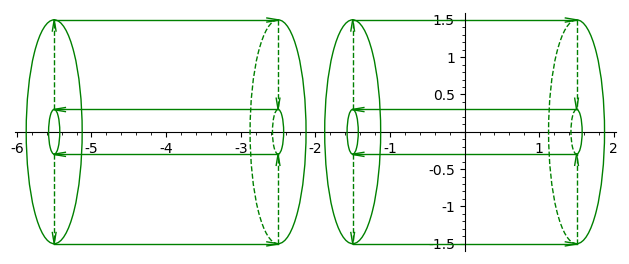

```python
line_thick = 0.005
arr_l = 0.15
arr_h = 0.025
color = "green"

def draw_cylinder(z0 = 0):
    p  = line ([[z0 + Zj1,      Rj2                 ], [z0 + Zj2,Rj2]], color = color)
    p += line ([[z0 + Zj2-arr_l,Rj2+arr_h           ], [z0 + Zj2,Rj2]], color = color)
    p += line ([[z0 + Zj2-arr_l,Rj2-arr_h-line_thick], [z0 + Zj2,Rj2-line_thick]], color = color)

    p += line ([[z0 + Zj2,      Rj2                 ], [z0 + Zj2,Rj1]], color = color, linestyle="dashed")
    p += line ([[z0 + Zj2-arr_h,Rj1+arr_l           ], [z0 + Zj2,Rj1]], color = color)
    p += line ([[z0 + Zj2+arr_h,Rj1+arr_l           ], [z0 + Zj2,Rj1]], color = color)

    p += line ([[z0 + Zj2,      Rj1                 ], [z0 + Zj1,Rj1]], color = color)
    p += line ([[z0 + Zj1+arr_l,Rj1+arr_h           ], [z0 + Zj1,Rj1]], color = color)
    p += line ([[z0 + Zj1+arr_l,Rj1-arr_h-line_thick], [z0 + Zj1,Rj1-line_thick]], color = color)

    p += line ([[z0 + Zj1,      Rj1                 ], [z0 + Zj1,Rj2]], color = color, linestyle="dashed")
    p += line ([[z0 + Zj1-arr_h,Rj2-arr_l           ], [z0 + Zj1,Rj2]], color = color)
    p += line ([[z0 + Zj1+arr_h,Rj2-arr_l           ], [z0 + Zj1,Rj2]], color = color)


    p += line ([[z0 + Zj1,      -Rj2                 ], [z0 + Zj2,-Rj2]], color = color)
    p += line ([[z0 + Zj2-arr_l,-Rj2+arr_h           ], [z0 + Zj2,-Rj2]], color = color)
    p += line ([[z0 + Zj2-arr_l,-Rj2-arr_h-line_thick], [z0 + Zj2,-Rj2-line_thick]], color = color)

    p += line ([[z0 + Zj2,      -Rj2                 ], [z0 + Zj2,-Rj1]], color = color, linestyle="dashed")
    p += line ([[z0 + Zj2-arr_h,-Rj1-arr_l           ], [z0 + Zj2,-Rj1]], color = color)
    p += line ([[z0 + Zj2+arr_h,-Rj1-arr_l           ], [z0 + Zj2,-Rj1]], color = color)


    p += line ([[z0 + Zj2,      -Rj1                 ], [z0 + Zj1,-Rj1]], color = color)
    p += line ([[z0 + Zj1+arr_l,-Rj1+arr_h           ], [z0 + Zj1,-Rj1]], color = color)
    p += line ([[z0 + Zj1+arr_l,-Rj1-arr_h-line_thick], [z0 + Zj1,-Rj1-line_thick]], color = color)

    p += line ([[z0 + Zj1,      -Rj1                 ], [z0 + Zj1,-Rj2]], color = color, linestyle="dashed")
    p += line ([[z0 + Zj1-arr_h,-Rj2+arr_l           ], [z0 + Zj1,-Rj2]], color = color)
    p += line ([[z0 + Zj1+arr_h,-Rj2+arr_l           ], [z0 + Zj1,-Rj2]], color = color)


    p += ellipse((z0 + Zj1, 0), (Rj1)/4, (Rj1), color = color)
    p += ellipse((z0 + Zj1, 0), (Rj2)/4, (Rj2), color = color)

    p += arc((z0 + Zj2, 0), (Rj1)/4, (Rj1), sector=(-pi/2,pi/2), color = color)
    p += arc((z0 + Zj2, 0), (Rj2)/4, (Rj2), sector=(-pi/2,pi/2), color = "green")

    p += arc((z0 + Zj2, 0), (Rj1)/4, (Rj1), sector=(pi/2,3*pi/2), color = color, linestyle="dashed")
    p += arc((z0 + Zj2, 0), (Rj2)/4, (Rj2), sector=(pi/2,3*pi/2), color = color, linestyle="dashed")

    return p

p = draw_cylinder()
p += draw_cylinder(z0 = -DZ-1.0)
p.show(aspect_ratio = 1, axes=True)
```

Следуя Тамму, обозначаем вектор намагниченности цилиндра через $I$. В данном расчёте предположим, что цилиндр имеет только $\varphi$-тую компоненту намагниченности и величина этой намагниченности постоянна в объёме ($I_{\varphi} = const$).

Для поверхностного тока у Тамма можно почерпнуть формулу $js = c \cdot [I \times n]$ (параграф 61. Векторный потенциал магнитного поля при наличии магнентиков. Средняя плотность объёмных и поверхностных токов. Уравнение 61.10 - случай для вакуума) Для объёмного тока - формулу $jv = c \cdot rot(I)$ (там же, уравнение 61.9)

В работе http://liquidcrystalosmos.narod.ru/deyna_cylinders_nikolaevs_experiment_31.htm было показано, что при равномерной тороидальной намагниченности цилиндра средняя плотность объёмных токов в данной конфигурации имеет только лишь $z$ компоненту, которая по модулю обратно пропорциональна радиус координате цилиндрической системы.

К этому же выводу можно прийти взяв ротор от $I$ при условии $I_{\varphi} = const$ в цилиндрических координатах

```python
c = var("c")    # скорость света
I0 = var("I0")  # намагниченность
js = c * I0     # плотность поверхностного тока на внутренней и внешней цилиндрической поверхностях цилиндра
                # js(rj1) = - c * I0
                # js(rj2) = + c * I0
jt = c * I0     # плотность поверхностного тока на торцах цилиндра
                # jt(zj1) = + c * I0
                # jt(zj2) = - c * I0
jv = - c * I0 / rj # плотность объёмного тока
```

```python
z_j = var("z_j")
z_a = var("z_a")
r_j = var("r_j")
r_a = var("r_a")
I_0 = var("I_0")  # намагниченность

latex_subs = [I0 == I_0, ra==r_a, za==z_a, zj==z_j, rj==r_j]
```

Зная среднюю плотность объёмных и поверхностных токов можно вычислить векторный потенциал магнитного поля тороидально намагниченного цилиндра. Следуя Тамму

$A=\frac{1}{c}\int{\frac{j_v}{R}}d{V}+\frac{1}{c}\int{\frac{j_s}{R}}d{S}$

Распишем в этом интеграле отдельно интегрирование по торцам и по цилиндрическим поверхностям

$A=\frac{1}{c}\int{\frac{j_v}{R}}d{V}+\frac{1}{c}\int{\frac{j_s}{R}}d{S_{s}}+\frac{1}{c}\int{\frac{j_t}{R}}d{S_{t}}$

В цилиндрической системе координат интегрирование по объёму цилиндра

$A_V=\frac{1}{c}\int{\frac{j_v}{R}}d{V}=\frac{1}{c}\int\limits_{{{r}_{j}}}\int\limits_{{{\varphi}_{j}}}\int\limits_{{{z}_{j}}} {\frac{j_v \left( {{r}_{j}} \right){{r}_{j}}}{R}\ }d{{z}_{j}}d{{\varphi }_{j}}d{{r}_{j}}$

интегрирование по цилиндрическим поверхностям цилиндра

$A_S=\frac{1}{c}\int{\frac{j_s}{R}}d{S_{s}}=\frac{1}{c}\int\limits_{{{\varphi}_{j}}}\int\limits_{{{z}_{j}}} {\frac{j_s \left( {{r}_{j}} \right){{r}_{j}}}{R}\ }d{{z}_{j}}d{{\varphi }_{j}}$

интегрирование по торцевым поверхностям цилиндра

$A_T=\frac{1}{c}\int{\frac{j_t}{R}}d{S_{t}}=\frac{1}{c}\int\limits_{{{r}_{j}}}\int\limits_{{{\varphi}_{j}}} {\frac{j_t \left( {{r}_{j}} \right){{r}_{j}}}{R}\ }d{{\varphi }_{j}}d{{r}_{j}}$

Во всех этих трёх интегралах нам потребуется интеграл $\int\limits_{0}^{2\pi}{\frac{1}{R}}d{\varphi}$ - обратного расстояния между точкой истока и точкой наблюдения в цилиндрической системе координат, проинтегрированный по координатному углу phi точек истока от нуля до $2\pi$

$R=\sqrt{(r_j\,sin(\varphi_j)-r_a\,sin(\varphi_a))^2+(r_j\,cos(\varphi_j)-r_a\,cos(\varphi_a))^2+(z_j-z_a)^2}$

Ввиду цилиндрической симметрии и ввиду того что

$\frac{\partial A}{\partial \varphi_a} = 0$

нам не потребуется дифференцирование векторного потенциала по $\varphi_a$ координате точек наблюдения, можно упростить расчёт полагая, что $\varphi_a = 0$, тогда

$R=\sqrt{r_j^2+r_a^2-2\,r_j\,r_a\,cos(\varphi_j)+(z_j-z_a)^2}$

В таком случае интеграл $IRphi=\int\limits_{0}^{2\pi}{\frac{1}{R}}d{\varphi_j}$ выражается через полный эллиптический интеграл первого рода следующим образом:

```python
from IPython.display import display, Math, Latex

rja2 = (rj-ra)^2+(zj-za)^2
module = - 4*rj*ra / rja2
IRphi=4*elliptic_kc(module) / sqrt(rja2)
display(Math("$$IR_{\\varphi} =" + latex(IRphi.subs(latex_subs)) + "$$"))
```

$$IR_{\varphi} = \frac{4 \, K\left(-\frac{4 \, r_{a} r_{j}}{{\left(r_{a} - r_{j}\right)}^{2} + {\left(z_{a} - z_{j}\right)}^{2}}\right)}{\sqrt{{\left(r_{a} - r_{j}\right)}^{2} + {\left(z_{a} - z_{j}\right)}^{2}}} $$

```python
z_j1 = var("z_j1") # левый торец цилиндра
z_j2 = var("z_j2") # правый торец цилиндра

r_j1 = var("r_j1") # радиус внутренней поверхности (сверления) цилиндра
r_j2 = var("r_j2") # радиус внешней цилиндрической поверхности цилиндра

latex_subs += [zj1 == z_j1, zj2==z_j2, rj1==r_j1, rj2==r_j2]
```

вспомогательные переменные для интегрирования источников векторного потенциала по поверхностным и объёмным токам

Интеграл по ${\varphi}_{j}$ векторного потенциала, создаваемого элементарным объёмом ${{r}_{j}}\,d{{\varphi}_{j}}d{r_j}d{z_j}$ цилиндра

$A_v=\frac{1}{c}\int\limits_{{{\varphi}_{j}}} {\frac{j_v \left( {{r}_{j}} \right){{r}_{j}}}{R}\ }d{{\varphi}_{j}}$

Интеграл по ${\varphi}_{j}$ векторного потенциала, создаваемого элементом площади ${{r}_{j}}\,d{{\varphi}_{j}}d{z_j}$ цилиндрической поверхности цилиндра

$A_s=\frac{1}{c}\int\limits_{{{\varphi}_{j}}} {\frac{j_s \left( {{r}_{j}} \right){{r}_{j}}}{R}\ }d{{\varphi}_{j}}$

Интеграл по ${\varphi}_{j}$ векторного потенциала, создаваемого элементом площади ${{r}_{j}}\,d{{\varphi}_{j}}d{r_j}$ торцевой поверхности цилиндра

$A_t=\frac{1}{c}\int\limits_{{{\varphi}_{j}}} {\frac{j_t \left( {{r}_{j}} \right){{r}_{j}}}{R}\ }d{{\varphi }_{j}}$

```python
As=IRphi*js*rj/c
display(Math("$$A_s =" + latex(As.subs(latex_subs)) + "$$"))

At=IRphi*jt*rj/c
display(Math("$$A_t =" + latex(At.subs(latex_subs)) + "$$"))

Av=IRphi*jv*rj/c
display(Math("$$A_v =" + latex(Av.subs(latex_subs)) + "$$"))
```

$$A_s = \frac{4 \, I_{0} r_{j} K\left(-\frac{4 \, r_{a} r_{j}}{{\left(r_{a} - r_{j}\right)}^{2} + {\left(z_{a} - z_{j}\right)}^{2}}\right)}{\sqrt{{\left(r_{a} - r_{j}\right)}^{2} + {\left(z_{a} - z_{j}\right)}^{2}}} $$

$$A_t = \frac{4 \, I_{0} r_{j} K\left(-\frac{4 \, r_{a} r_{j}}{{\left(r_{a} - r_{j}\right)}^{2} + {\left(z_{a} - z_{j}\right)}^{2}}\right)}{\sqrt{{\left(r_{a} - r_{j}\right)}^{2} + {\left(z_{a} - z_{j}\right)}^{2}}} $$

$$A_v = -\frac{4 \, I_{0} K\left(-\frac{4 \, r_{a} r_{j}}{{\left(r_{a} - r_{j}\right)}^{2} + {\left(z_{a} - z_{j}\right)}^{2}}\right)}{\sqrt{{\left(r_{a} - r_{j}\right)}^{2} + {\left(z_{a} - z_{j}\right)}^{2}}} $$

Рассчитаем производную векторного потенциала, создаваемого торцевым поверхностным током, по $z_a$ координате точки наблюдения $\frac{\partial}{\partial z_a} A_t = \frac{\partial}{\partial z_a}\int\limits_{{{\varphi}_{j}}} {\frac{j_t \left( {{r}_{j}} \right){{r}_{j}}}{R}\ }d{{\varphi }_{j}}$

```python
At_diff_za_ = lambda I0, r_j, r_a, z_j, z_a : (At.diff(za)).substitute(ra==r_a).substitute(za==z_a).substitute(zj==z_j).substitute(rj==r_j)
```

Итак, производная векторного потенциала, создаваемого торцевым поверхностным током, заключённом в плоском кольце толщиной $dr_j$ с радиусом $r_j$, по $z_a$ координате точки наблюдения

```python
display(Math("$$\\frac{\\partial}{\\partial z_a} A_t(I_0, rj, ra, zj, za) = " + latex(At_diff_za_(I0, rj, ra, zj, za).subs(latex_subs)) + "$$"))
```

$$\frac{\partial}{\partial z_a} A_t(I_0, rj, ra, zj, za) = -\frac{4 \, I_{0} r_{j} {\left(z_{a} - z_{j}\right)} K\left(-\frac{4 \, r_{a} r_{j}}{{\left(r_{a} - r_{j}\right)}^{2} + {\left(z_{a} - z_{j}\right)}^{2}}\right)}{{\left({\left(r_{a} - r_{j}\right)}^{2} + {\left(z_{a} - z_{j}\right)}^{2}\right)}^{\frac{3}{2}}} + \frac{4 \, {\left({\left(\frac{4 \, r_{a} r_{j}}{{\left(r_{a} - r_{j}\right)}^{2} + {\left(z_{a} - z_{j}\right)}^{2}} + 1\right)} K\left(-\frac{4 \, r_{a} r_{j}}{{\left(r_{a} - r_{j}\right)}^{2} + {\left(z_{a} - z_{j}\right)}^{2}}\right) - E\left(-\frac{4 \, r_{a} r_{j}}{{\left(r_{a} - r_{j}\right)}^{2} + {\left(z_{a} - z_{j}\right)}^{2}}\right)\right)} I_{0} r_{j} {\left(z_{a} - z_{j}\right)}}{{\left({\left(r_{a} - r_{j}\right)}^{2} + {\left(z_{a} - z_{j}\right)}^{2}\right)}^{\frac{3}{2}} {\left(\frac{4 \, r_{a} r_{j}}{{\left(r_{a} - r_{j}\right)}^{2} + {\left(z_{a} - z_{j}\right)}^{2}} + 1\right)}} $$

```python
exec(preparse("At_diff_za = lambda I0, rj, ra, zj, za : " + str(At_diff_za_(I0, rj, ra, zj, za))))
```

```python
print (At_diff_za (I0, rj, ra, zj, za))
```

```
-4*I0*rj*(za - zj)*elliptic_kc(-4*ra*rj/((ra - rj)^2 + (za - zj)^2))/((ra - rj)^2 + (za - zj)^2)^(3/2) + 4*((4*ra*rj/((ra - rj)^2 + (za - zj)^2) + 1)*elliptic_kc(-4*ra*rj/((ra - rj)^2 + (za - zj)^2)) - elliptic_ec(-4*ra*rj/((ra - rj)^2 + (za - zj)^2)))*I0*rj*(za - zj)/(((ra - rj)^2 + (za - zj)^2)^(3…
```

```python
display(Math(latex(At_diff_za (I0, rj, ra, zj, za).subs(latex_subs))))
```

$$-\frac{4 \, I_{0} r_{j} {\left(z_{a} - z_{j}\right)} K\left(-\frac{4 \, r_{a} r_{j}}{{\left(r_{a} - r_{j}\right)}^{2} + {\left(z_{a} - z_{j}\right)}^{2}}\right)}{{\left({\left(r_{a} - r_{j}\right)}^{2} + {\left(z_{a} - z_{j}\right)}^{2}\right)}^{\frac{3}{2}}} + \frac{4 \, {\left({\left(\frac{4 \, r_{a} r_{j}}{{\left(r_{a} - r_{j}\right)}^{2} + {\left(z_{a} - z_{j}\right)}^{2}} + 1\right)} K\left(-\frac{4 \, r_{a} r_{j}}{{\left(r_{a} - r_{j}\right)}^{2} + {\left(z_{a} - z_{j}\right)}^{2}}\right) - E\left(-\frac{4 \, r_{a} r_{j}}{{\left(r_{a} - r_{j}\right)}^{2} + {\left(z_{a} - z_{j}\right)}^{2}}\right)\right)} I_{0} r_{j} {\left(z_{a} - z_{j}\right)}}{{\left({\left(r_{a} - r_{j}\right)}^{2} + {\left(z_{a} - z_{j}\right)}^{2}\right)}^{\frac{3}{2}} {\left(\frac{4 \, r_{a} r_{j}}{{\left(r_{a} - r_{j}\right)}^{2} + {\left(z_{a} - z_{j}\right)}^{2}} + 1\right)}}$$

Учитывая положительное направление поверхностного тока в левом торце и отрицательное направление поверхностного тока в правом торце составим сумму полученной производной для обоих торцов

```python
At2_diff_za_ = lambda I0, rj, ra, zj1, zj2, za : At_diff_za_(I0, rj, ra, zj1, za) - At_diff_za_(I0, rj, ra, zj2, za)
```

Итак, производная векторного потенциала, создаваемого торцевым поверхностным током обоих торцов, заключённом в двух плоских кольцах толщиной $dr_{j}$ и радиуса $r_{j}$, по $z$ координате точки наблюдения

```python
exec(preparse("At2_diff_za = lambda I0, rj, ra, zj1, zj2, za : " + str(At2_diff_za_(I0, rj, ra, zj1, zj2, za))))
```

```python
print(At2_diff_za (I0, rj, ra, zj1, zj2, za))
```

```
-4*I0*rj*(za - zj1)*elliptic_kc(-4*ra*rj/((ra - rj)^2 + (za - zj1)^2))/((ra - rj)^2 + (za - zj1)^2)^(3/2) + 4*I0*rj*(za - zj2)*elliptic_kc(-4*ra*rj/((ra - rj)^2 + (za - zj2)^2))/((ra - rj)^2 + (za - zj2)^2)^(3/2) + 4*((4*ra*rj/((ra - rj)^2 + (za - zj1)^2) + 1)*elliptic_kc(-4*ra*rj/((ra - rj)^2 + (za…
```

```python
display(Math(latex(At2_diff_za (I0, rj, ra, zj1, zj2, za).subs(latex_subs))))
```

$$-\frac{4 \, I_{0} r_{j} {\left(z_{a} - z_{j_{1}}\right)} K\left(-\frac{4 \, r_{a} r_{j}}{{\left(r_{a} - r_{j}\right)}^{2} + {\left(z_{a} - z_{j_{1}}\right)}^{2}}\right)}{{\left({\left(r_{a} - r_{j}\right)}^{2} + {\left(z_{a} - z_{j_{1}}\right)}^{2}\right)}^{\frac{3}{2}}} + \frac{4 \, I_{0} r_{j} {\left(z_{a} - z_{j_{2}}\right)} K\left(-\frac{4 \, r_{a} r_{j}}{{\left(r_{a} - r_{j}\right)}^{2} + {\left(z_{a} - z_{j_{2}}\right)}^{2}}\right)}{{\left({\left(r_{a} - r_{j}\right)}^{2} + {\left(z_{a} - z_{j_{2}}\right)}^{2}\right)}^{\frac{3}{2}}} + \frac{4 \, {\left({\left(\frac{4 \, r_{a} r_{j}}{{\left(r_{a} - r_{j}\right)}^{2} + {\left(z_{a} - z_{j_{1}}\right)}^{2}} + 1\right)} K\left(-\frac{4 \, r_{a} r_{j}}{{\left(r_{a} - r_{j}\right)}^{2} + {\left(z_{a} - z_{j_{1}}\right)}^{2}}\right) - E\left(-\frac{4 \, r_{a} r_{j}}{{\left(r_{a} - r_{j}\right)}^{2} + {\left(z_{a} - z_{j_{1}}\right)}^{2}}\right)\right)} I_{0} r_{j} {\left(z_{a} - z_{j_{1}}\right)}}{{\left({\left(r_{a} - r_{j}\right)}^{2} + {\left(z_{a} - z_{j_{1}}\right)}^{2}\right)}^{\frac{3}{2}} {\left(\frac{4 \, r_{a} r_{j}}{{\left(r_{a} - r_{j}\right)}^{2} + {\left(z_{a} - z_{j_{1}}\right)}^{2}} + 1\right)}} - \frac{4 \, {\left({\left(\frac{4 \, r_{a} r_{j}}{{\left(r_{a} - r_{j}\right)}^{2} + {\left(z_{a} - z_{j_{2}}\right)}^{2}} + 1\right)} K\left(-\frac{4 \, r_{a} r_{j}}{{\left(r_{a} - r_{j}\right)}^{2} + {\left(z_{a} - z_{j_{2}}\right)}^{2}}\right) - E\left(-\frac{4 \, r_{a} r_{j}}{{\left(r_{a} - r_{j}\right)}^{2} + {\left(z_{a} - z_{j_{2}}\right)}^{2}}\right)\right)} I_{0} r_{j} {\left(z_{a} - z_{j_{2}}\right)}}{{\left({\left(r_{a} - r_{j}\right)}^{2} + {\left(z_{a} - z_{j_{2}}\right)}^{2}\right)}^{\frac{3}{2}} {\left(\frac{4 \, r_{a} r_{j}}{{\left(r_{a} - r_{j}\right)}^{2} + {\left(z_{a} - z_{j_{2}}\right)}^{2}} + 1\right)}}$$

Рассчитаем производную векторного потенциала, создаваемого торцевым поверхностным током, по $r_a$ координате точки наблюдения $\frac{1}{r_a}\frac{\partial}{\partial r_a}\left(r_a\,A_t\right) = \frac{1}{r_a}\frac{\partial}{\partial r_a}\left(r_a\,\int\limits_{{{\varphi}_{j}}} {\frac{j_t \left( {{r}_{j}} \right){{r}_{j}}}{R}\ }d{{\varphi }_{j}}\right)$

```python
At_ra_diff_ra_div_ra_ = lambda I0, r_j, r_a, z_j, z_a : ((ra*At).diff(ra)/ra).substitute(ra==r_a).substitute(za==z_a).substitute(zj==z_j).substitute(rj==r_j)
```

Итак, производная векторного потенциала, создаваемого торцевым поверхностным током, заключённом в плоском кольце толщиной $dr_j$ с радиусом $r_j$, по $r_a$ координате точки наблюдения

```python
display(Math("$$\\frac{1}{r_a}\\frac{\\partial}{\\partial r_a}\\left(r_a\\, A_t(I_0, rj, ra, zj, za)\\right) = " + latex(At_ra_diff_ra_div_ra_(I0, rj, ra, zj, za).subs(latex_subs)) + "$$"))
```

$$\frac{1}{r_a}\frac{\partial}{\partial r_a}\left(r_a\, A_t(I_0, rj, ra, zj, za)\right) = -\frac{2 \, {\left(\frac{2 \, I_{0} {\left(r_{a} - r_{j}\right)} r_{a} r_{j} K\left(-\frac{4 \, r_{a} r_{j}}{{\left(r_{a} - r_{j}\right)}^{2} + {\left(z_{a} - z_{j}\right)}^{2}}\right)}{{\left({\left(r_{a} - r_{j}\right)}^{2} + {\left(z_{a} - z_{j}\right)}^{2}\right)}^{\frac{3}{2}}} - \frac{\sqrt{{\left(r_{a} - r_{j}\right)}^{2} + {\left(z_{a} - z_{j}\right)}^{2}} {\left({\left(\frac{4 \, r_{a} r_{j}}{{\left(r_{a} - r_{j}\right)}^{2} + {\left(z_{a} - z_{j}\right)}^{2}} + 1\right)} K\left(-\frac{4 \, r_{a} r_{j}}{{\left(r_{a} - r_{j}\right)}^{2} + {\left(z_{a} - z_{j}\right)}^{2}}\right) - E\left(-\frac{4 \, r_{a} r_{j}}{{\left(r_{a} - r_{j}\right)}^{2} + {\left(z_{a} - z_{j}\right)}^{2}}\right)\right)} I_{0} {\left(\frac{2 \, {\left(r_{a} - r_{j}\right)} r_{a} r_{j}}{{\left({\left(r_{a} - r_{j}\right)}^{2} + {\left(z_{a} - z_{j}\right)}^{2}\right)}^{2}} - \frac{r_{j}}{{\left(r_{a} - r_{j}\right)}^{2} + {\left(z_{a} - z_{j}\right)}^{2}}\right)}}{\frac{4 \, r_{a} r_{j}}{{\left(r_{a} - r_{j}\right)}^{2} + {\left(z_{a} - z_{j}\right)}^{2}} + 1} - \frac{2 \, I_{0} r_{j} K\left(-\frac{4 \, r_{a} r_{j}}{{\left(r_{a} - r_{j}\right)}^{2} + {\left(z_{a} - z_{j}\right)}^{2}}\right)}{\sqrt{{\left(r_{a} - r_{j}\right)}^{2} + {\left(z_{a} - z_{j}\right)}^{2}}}\right)}}{r_{a}} $$

```python
exec(preparse("At_ra_diff_ra_div_ra = lambda I0, rj, ra, zj, za : " + str(At_ra_diff_ra_div_ra_(I0, rj, ra, zj, za))))
```

```python
print (At_ra_diff_ra_div_ra (I0, rj, ra, zj, za))
```

```
-2*(2*I0*(ra - rj)*ra*rj*elliptic_kc(-4*ra*rj/((ra - rj)^2 + (za - zj)^2))/((ra - rj)^2 + (za - zj)^2)^(3/2) - sqrt((ra - rj)^2 + (za - zj)^2)*((4*ra*rj/((ra - rj)^2 + (za - zj)^2) + 1)*elliptic_kc(-4*ra*rj/((ra - rj)^2 + (za - zj)^2)) - elliptic_ec(-4*ra*rj/((ra - rj)^2 + (za - zj)^2)))*I0*(2*(ra -…
```

```python
display(Math(latex(At_ra_diff_ra_div_ra (I0, rj, ra, zj, za).subs(latex_subs))))
```

$$-\frac{2 \, {\left(\frac{2 \, I_{0} {\left(r_{a} - r_{j}\right)} r_{a} r_{j} K\left(-\frac{4 \, r_{a} r_{j}}{{\left(r_{a} - r_{j}\right)}^{2} + {\left(z_{a} - z_{j}\right)}^{2}}\right)}{{\left({\left(r_{a} - r_{j}\right)}^{2} + {\left(z_{a} - z_{j}\right)}^{2}\right)}^{\frac{3}{2}}} - \frac{\sqrt{{\left(r_{a} - r_{j}\right)}^{2} + {\left(z_{a} - z_{j}\right)}^{2}} {\left({\left(\frac{4 \, r_{a} r_{j}}{{\left(r_{a} - r_{j}\right)}^{2} + {\left(z_{a} - z_{j}\right)}^{2}} + 1\right)} K\left(-\frac{4 \, r_{a} r_{j}}{{\left(r_{a} - r_{j}\right)}^{2} + {\left(z_{a} - z_{j}\right)}^{2}}\right) - E\left(-\frac{4 \, r_{a} r_{j}}{{\left(r_{a} - r_{j}\right)}^{2} + {\left(z_{a} - z_{j}\right)}^{2}}\right)\right)} I_{0} {\left(\frac{2 \, {\left(r_{a} - r_{j}\right)} r_{a} r_{j}}{{\left({\left(r_{a} - r_{j}\right)}^{2} + {\left(z_{a} - z_{j}\right)}^{2}\right)}^{2}} - \frac{r_{j}}{{\left(r_{a} - r_{j}\right)}^{2} + {\left(z_{a} - z_{j}\right)}^{2}}\right)}}{\frac{4 \, r_{a} r_{j}}{{\left(r_{a} - r_{j}\right)}^{2} + {\left(z_{a} - z_{j}\right)}^{2}} + 1} - \frac{2 \, I_{0} r_{j} K\left(-\frac{4 \, r_{a} r_{j}}{{\left(r_{a} - r_{j}\right)}^{2} + {\left(z_{a} - z_{j}\right)}^{2}}\right)}{\sqrt{{\left(r_{a} - r_{j}\right)}^{2} + {\left(z_{a} - z_{j}\right)}^{2}}}\right)}}{r_{a}}$$

Учитывая положительное направление поверхностного тока в левом торце и отрицательное направление поверхностного тока в правом торце составим сумму полученной производной для обоих торцов

```python
At2_ra_diff_ra_div_ra_ = lambda I0, rj, ra, zj1, zj2, za : At_ra_diff_ra_div_ra_(I0, rj, ra, zj1, za) - At_ra_diff_ra_div_ra_(I0, rj, ra, zj2, za)
```

```python
#str(At2_ra_diff_ra_div_ra_(I0, rj, ra, zj1, zj2, za))
```

Итак, производная векторного потенциала, создаваемого торцевым поверхностным током обоих торцов, заключённом в двух плоских кольцах толщиной $dr_{j}$ и радиуса $r_{j}$, по $r$ координате точки наблюдения

```python
exec(preparse("At2_ra_diff_ra_div_ra = lambda I0, rj, ra, zj1, zj2, za : " + str(At2_ra_diff_ra_div_ra_(I0, rj, ra, zj1, zj2, za))))
```

```python
print(At2_ra_diff_ra_div_ra (I0, rj, ra, zj1, zj2, za))
```

```
-2*(2*I0*(ra - rj)*ra*rj*elliptic_kc(-4*ra*rj/((ra - rj)^2 + (za - zj1)^2))/((ra - rj)^2 + (za - zj1)^2)^(3/2) - sqrt((ra - rj)^2 + (za - zj1)^2)*((4*ra*rj/((ra - rj)^2 + (za - zj1)^2) + 1)*elliptic_kc(-4*ra*rj/((ra - rj)^2 + (za - zj1)^2)) - elliptic_ec(-4*ra*rj/((ra - rj)^2 + (za - zj1)^2)))*I0*(2…
```

```python
display(Math(latex(At2_ra_diff_ra_div_ra (I0, rj, ra, zj1, zj2, za).subs(latex_subs))))
```

$$-\frac{2 \, {\left(\frac{2 \, I_{0} {\left(r_{a} - r_{j}\right)} r_{a} r_{j} K\left(-\frac{4 \, r_{a} r_{j}}{{\left(r_{a} - r_{j}\right)}^{2} + {\left(z_{a} - z_{j_{1}}\right)}^{2}}\right)}{{\left({\left(r_{a} - r_{j}\right)}^{2} + {\left(z_{a} - z_{j_{1}}\right)}^{2}\right)}^{\frac{3}{2}}} - \frac{\sqrt{{\left(r_{a} - r_{j}\right)}^{2} + {\left(z_{a} - z_{j_{1}}\right)}^{2}} {\left({\left(\frac{4 \, r_{a} r_{j}}{{\left(r_{a} - r_{j}\right)}^{2} + {\left(z_{a} - z_{j_{1}}\right)}^{2}} + 1\right)} K\left(-\frac{4 \, r_{a} r_{j}}{{\left(r_{a} - r_{j}\right)}^{2} + {\left(z_{a} - z_{j_{1}}\right)}^{2}}\right) - E\left(-\frac{4 \, r_{a} r_{j}}{{\left(r_{a} - r_{j}\right)}^{2} + {\left(z_{a} - z_{j_{1}}\right)}^{2}}\right)\right)} I_{0} {\left(\frac{2 \, {\left(r_{a} - r_{j}\right)} r_{a} r_{j}}{{\left({\left(r_{a} - r_{j}\right)}^{2} + {\left(z_{a} - z_{j_{1}}\right)}^{2}\right)}^{2}} - \frac{r_{j}}{{\left(r_{a} - r_{j}\right)}^{2} + {\left(z_{a} - z_{j_{1}}\right)}^{2}}\right)}}{\frac{4 \, r_{a} r_{j}}{{\left(r_{a} - r_{j}\right)}^{2} + {\left(z_{a} - z_{j_{1}}\right)}^{2}} + 1} - \frac{2 \, I_{0} r_{j} K\left(-\frac{4 \, r_{a} r_{j}}{{\left(r_{a} - r_{j}\right)}^{2} + {\left(z_{a} - z_{j_{1}}\right)}^{2}}\right)}{\sqrt{{\left(r_{a} - r_{j}\right)}^{2} + {\left(z_{a} - z_{j_{1}}\right)}^{2}}}\right)}}{r_{a}} + \frac{2 \, {\left(\frac{2 \, I_{0} {\left(r_{a} - r_{j}\right)} r_{a} r_{j} K\left(-\frac{4 \, r_{a} r_{j}}{{\left(r_{a} - r_{j}\right)}^{2} + {\left(z_{a} - z_{j_{2}}\right)}^{2}}\right)}{{\left({\left(r_{a} - r_{j}\right)}^{2} + {\left(z_{a} - z_{j_{2}}\right)}^{2}\right)}^{\frac{3}{2}}} - \frac{\sqrt{{\left(r_{a} - r_{j}\right)}^{2} + {\left(z_{a} - z_{j_{2}}\right)}^{2}} {\left({\left(\frac{4 \, r_{a} r_{j}}{{\left(r_{a} - r_{j}\right)}^{2} + {\left(z_{a} - z_{j_{2}}\right)}^{2}} + 1\right)} K\left(-\frac{4 \, r_{a} r_{j}}{{\left(r_{a} - r_{j}\right)}^{2} + {\left(z_{a} - z_{j_{2}}\right)}^{2}}\right) - E\left(-\frac{4 \, r_{a} r_{j}}{{\left(r_{a} - r_{j}\right)}^{2} + {\left(z_{a} - z_{j_{2}}\right)}^{2}}\right)\right)} I_{0} {\left(\frac{2 \, {\left(r_{a} - r_{j}\right)} r_{a} r_{j}}{{\left({\left(r_{a} - r_{j}\right)}^{2} + {\left(z_{a} - z_{j_{2}}\right)}^{2}\right)}^{2}} - \frac{r_{j}}{{\left(r_{a} - r_{j}\right)}^{2} + {\left(z_{a} - z_{j_{2}}\right)}^{2}}\right)}}{\frac{4 \, r_{a} r_{j}}{{\left(r_{a} - r_{j}\right)}^{2} + {\left(z_{a} - z_{j_{2}}\right)}^{2}} + 1} - \frac{2 \, I_{0} r_{j} K\left(-\frac{4 \, r_{a} r_{j}}{{\left(r_{a} - r_{j}\right)}^{2} + {\left(z_{a} - z_{j_{2}}\right)}^{2}}\right)}{\sqrt{{\left(r_{a} - r_{j}\right)}^{2} + {\left(z_{a} - z_{j_{2}}\right)}^{2}}}\right)}}{r_{a}}$$

Рассчитаем производную векторного потенциала, создаваемого поверхностным током цилиндрической поверхности, по $r_a$ координате точки наблюдения $\frac{\partial}{\partial r_a} A_s = \frac{\partial}{\partial r_a}\int\limits_{{{\varphi}_{j}}} {\frac{j_s \left( {{r}_{j}} \right){{r}_{j}}}{R}\ }d{{\varphi }_{j}}$

```python
As_diff_ra_ = lambda I0, r_j, r_a, z_j, z_a : (As.diff(ra)).substitute(ra==r_a).substitute(za==z_a).substitute(zj==z_j).substitute(rj==r_j)
```

Итак, производная векторного потенциала, создаваемого поверхностным током цилиндрической поверхности радиуса $r_{j}$, заключённой в поверхностном кольце шириной $dz_{j}$ c координатой $z_{j}$, по $r$ координате точки наблюдения

```python
display(Math("$$\\frac{\\partial}{\\partial r_a} A_s (I0, rj, ra, zj, za) = " + latex(As_diff_ra_(I0, rj, ra, zj, za).subs(latex_subs)) + "$$"))
```

$$\frac{\partial}{\partial r_a} A_s (I0, rj, ra, zj, za) = -\frac{4 \, I_{0} {\left(r_{a} - r_{j}\right)} r_{j} K\left(-\frac{4 \, r_{a} r_{j}}{{\left(r_{a} - r_{j}\right)}^{2} + {\left(z_{a} - z_{j}\right)}^{2}}\right)}{{\left({\left(r_{a} - r_{j}\right)}^{2} + {\left(z_{a} - z_{j}\right)}^{2}\right)}^{\frac{3}{2}}} + \frac{2 \, \sqrt{{\left(r_{a} - r_{j}\right)}^{2} + {\left(z_{a} - z_{j}\right)}^{2}} {\left({\left(\frac{4 \, r_{a} r_{j}}{{\left(r_{a} - r_{j}\right)}^{2} + {\left(z_{a} - z_{j}\right)}^{2}} + 1\right)} K\left(-\frac{4 \, r_{a} r_{j}}{{\left(r_{a} - r_{j}\right)}^{2} + {\left(z_{a} - z_{j}\right)}^{2}}\right) - E\left(-\frac{4 \, r_{a} r_{j}}{{\left(r_{a} - r_{j}\right)}^{2} + {\left(z_{a} - z_{j}\right)}^{2}}\right)\right)} I_{0} {\left(\frac{2 \, {\left(r_{a} - r_{j}\right)} r_{a} r_{j}}{{\left({\left(r_{a} - r_{j}\right)}^{2} + {\left(z_{a} - z_{j}\right)}^{2}\right)}^{2}} - \frac{r_{j}}{{\left(r_{a} - r_{j}\right)}^{2} + {\left(z_{a} - z_{j}\right)}^{2}}\right)}}{r_{a} {\left(\frac{4 \, r_{a} r_{j}}{{\left(r_{a} - r_{j}\right)}^{2} + {\left(z_{a} - z_{j}\right)}^{2}} + 1\right)}} $$

```python
exec(preparse("As_diff_ra = lambda I0, rj, ra, zj, za : " + str(As_diff_ra_(I0, rj, ra, zj, za))))
```

```python
print(As_diff_ra (I0, rj, ra, zj, za))
```

```
-4*I0*(ra - rj)*rj*elliptic_kc(-4*ra*rj/((ra - rj)^2 + (za - zj)^2))/((ra - rj)^2 + (za - zj)^2)^(3/2) + 2*sqrt((ra - rj)^2 + (za - zj)^2)*((4*ra*rj/((ra - rj)^2 + (za - zj)^2) + 1)*elliptic_kc(-4*ra*rj/((ra - rj)^2 + (za - zj)^2)) - elliptic_ec(-4*ra*rj/((ra - rj)^2 + (za - zj)^2)))*I0*(2*(ra - rj)…
```

```python
display(Math(latex(As_diff_ra (I0, rj, ra, zj, za).subs(latex_subs))))
```

$$-\frac{4 \, I_{0} {\left(r_{a} - r_{j}\right)} r_{j} K\left(-\frac{4 \, r_{a} r_{j}}{{\left(r_{a} - r_{j}\right)}^{2} + {\left(z_{a} - z_{j}\right)}^{2}}\right)}{{\left({\left(r_{a} - r_{j}\right)}^{2} + {\left(z_{a} - z_{j}\right)}^{2}\right)}^{\frac{3}{2}}} + \frac{2 \, \sqrt{{\left(r_{a} - r_{j}\right)}^{2} + {\left(z_{a} - z_{j}\right)}^{2}} {\left({\left(\frac{4 \, r_{a} r_{j}}{{\left(r_{a} - r_{j}\right)}^{2} + {\left(z_{a} - z_{j}\right)}^{2}} + 1\right)} K\left(-\frac{4 \, r_{a} r_{j}}{{\left(r_{a} - r_{j}\right)}^{2} + {\left(z_{a} - z_{j}\right)}^{2}}\right) - E\left(-\frac{4 \, r_{a} r_{j}}{{\left(r_{a} - r_{j}\right)}^{2} + {\left(z_{a} - z_{j}\right)}^{2}}\right)\right)} I_{0} {\left(\frac{2 \, {\left(r_{a} - r_{j}\right)} r_{a} r_{j}}{{\left({\left(r_{a} - r_{j}\right)}^{2} + {\left(z_{a} - z_{j}\right)}^{2}\right)}^{2}} - \frac{r_{j}}{{\left(r_{a} - r_{j}\right)}^{2} + {\left(z_{a} - z_{j}\right)}^{2}}\right)}}{r_{a} {\left(\frac{4 \, r_{a} r_{j}}{{\left(r_{a} - r_{j}\right)}^{2} + {\left(z_{a} - z_{j}\right)}^{2}} + 1\right)}}$$

Учитывая отрицательное направление поверхностного тока на внутренней цилиндрической поверхности (в сверлении) и положительное направление поверхностного тока на внешней цилиндрической поверхности составим сумму полученной производной для обоих цилиндрических поверхностей

```python
As2_diff_ra_ = lambda I0, rj1, rj2, ra, zj, za : - As_diff_ra_(I0, rj1, ra, zj, za) + As_diff_ra_(I0, rj2, ra, zj, za)
```

Итак, производная векторного потенциала, создаваемого поверхностными токами обоих цилиндрических поверхностей, заключённом в двух поверхностных кольцах шириной $dz_{j}$ c координатой $z_{j}$, по $r$ координате точки наблюдения

```python
exec(preparse("As2_diff_ra = lambda I0, rj1, rj2, ra, zj, za : " + str(As2_diff_ra_(I0, rj1, rj2, ra, zj, za))))
```

```python
print (As2_diff_ra (I0, rj1, rj2, ra, zj, za))
```

```
4*I0*(ra - rj1)*rj1*elliptic_kc(-4*ra*rj1/((ra - rj1)^2 + (za - zj)^2))/((ra - rj1)^2 + (za - zj)^2)^(3/2) - 4*I0*(ra - rj2)*rj2*elliptic_kc(-4*ra*rj2/((ra - rj2)^2 + (za - zj)^2))/((ra - rj2)^2 + (za - zj)^2)^(3/2) - 2*sqrt((ra - rj1)^2 + (za - zj)^2)*((4*ra*rj1/((ra - rj1)^2 + (za - zj)^2) + 1)*el…
```

```python
display(Math(latex(As2_diff_ra (I0, rj1, rj2, ra, zj, za).subs(latex_subs))))
```

$$\frac{4 \, I_{0} {\left(r_{a} - r_{j_{1}}\right)} r_{j_{1}} K\left(-\frac{4 \, r_{a} r_{j_{1}}}{{\left(r_{a} - r_{j_{1}}\right)}^{2} + {\left(z_{a} - z_{j}\right)}^{2}}\right)}{{\left({\left(r_{a} - r_{j_{1}}\right)}^{2} + {\left(z_{a} - z_{j}\right)}^{2}\right)}^{\frac{3}{2}}} - \frac{4 \, I_{0} {\left(r_{a} - r_{j_{2}}\right)} r_{j_{2}} K\left(-\frac{4 \, r_{a} r_{j_{2}}}{{\left(r_{a} - r_{j_{2}}\right)}^{2} + {\left(z_{a} - z_{j}\right)}^{2}}\right)}{{\left({\left(r_{a} - r_{j_{2}}\right)}^{2} + {\left(z_{a} - z_{j}\right)}^{2}\right)}^{\frac{3}{2}}} - \frac{2 \, \sqrt{{\left(r_{a} - r_{j_{1}}\right)}^{2} + {\left(z_{a} - z_{j}\right)}^{2}} {\left({\left(\frac{4 \, r_{a} r_{j_{1}}}{{\left(r_{a} - r_{j_{1}}\right)}^{2} + {\left(z_{a} - z_{j}\right)}^{2}} + 1\right)} K\left(-\frac{4 \, r_{a} r_{j_{1}}}{{\left(r_{a} - r_{j_{1}}\right)}^{2} + {\left(z_{a} - z_{j}\right)}^{2}}\right) - E\left(-\frac{4 \, r_{a} r_{j_{1}}}{{\left(r_{a} - r_{j_{1}}\right)}^{2} + {\left(z_{a} - z_{j}\right)}^{2}}\right)\right)} I_{0} {\left(\frac{2 \, {\left(r_{a} - r_{j_{1}}\right)} r_{a} r_{j_{1}}}{{\left({\left(r_{a} - r_{j_{1}}\right)}^{2} + {\left(z_{a} - z_{j}\right)}^{2}\right)}^{2}} - \frac{r_{j_{1}}}{{\left(r_{a} - r_{j_{1}}\right)}^{2} + {\left(z_{a} - z_{j}\right)}^{2}}\right)}}{r_{a} {\left(\frac{4 \, r_{a} r_{j_{1}}}{{\left(r_{a} - r_{j_{1}}\right)}^{2} + {\left(z_{a} - z_{j}\right)}^{2}} + 1\right)}} + \frac{2 \, \sqrt{{\left(r_{a} - r_{j_{2}}\right)}^{2} + {\left(z_{a} - z_{j}\right)}^{2}} {\left({\left(\frac{4 \, r_{a} r_{j_{2}}}{{\left(r_{a} - r_{j_{2}}\right)}^{2} + {\left(z_{a} - z_{j}\right)}^{2}} + 1\right)} K\left(-\frac{4 \, r_{a} r_{j_{2}}}{{\left(r_{a} - r_{j_{2}}\right)}^{2} + {\left(z_{a} - z_{j}\right)}^{2}}\right) - E\left(-\frac{4 \, r_{a} r_{j_{2}}}{{\left(r_{a} - r_{j_{2}}\right)}^{2} + {\left(z_{a} - z_{j}\right)}^{2}}\right)\right)} I_{0} {\left(\frac{2 \, {\left(r_{a} - r_{j_{2}}\right)} r_{a} r_{j_{2}}}{{\left({\left(r_{a} - r_{j_{2}}\right)}^{2} + {\left(z_{a} - z_{j}\right)}^{2}\right)}^{2}} - \frac{r_{j_{2}}}{{\left(r_{a} - r_{j_{2}}\right)}^{2} + {\left(z_{a} - z_{j}\right)}^{2}}\right)}}{r_{a} {\left(\frac{4 \, r_{a} r_{j_{2}}}{{\left(r_{a} - r_{j_{2}}\right)}^{2} + {\left(z_{a} - z_{j}\right)}^{2}} + 1\right)}}$$

Рассчитаем производную векторного потенциала, создаваемого поверхностным током цилиндрической поверхности, по $z_a$ координате точки наблюдения $\frac{\partial}{\partial z_a} A_s = \frac{\partial}{\partial z_a}\int\limits_{{{\varphi}_{j}}} {\frac{j_s \left( {{r}_{j}} \right){{r}_{j}}}{R}\ }d{{\varphi }_{j}}$

```python
As_diff_za_ = lambda I0, r_j, r_a, z_j, z_a : (As.diff(za)).substitute(ra==r_a).substitute(za==z_a).substitute(zj==z_j).substitute(rj==r_j)
```

Итак, производная векторного потенциала, создаваемого поверхностным током цилиндрической поверхности радиуса $r_{j}$, заключённой в поверхностном кольце шириной $dz_{j}$ c координатой $z_{j}$, по $z$ координате точки наблюдения

```python
display(Math("$$\\frac{\\partial}{\\partial z_a} A_s (I0, rj, ra, zj, za) = " + latex(As_diff_za_(I0, rj, ra, zj, za).subs(latex_subs)) + "$$"))
```

$$\frac{\partial}{\partial z_a} A_s (I0, rj, ra, zj, za) = -\frac{4 \, I_{0} r_{j} {\left(z_{a} - z_{j}\right)} K\left(-\frac{4 \, r_{a} r_{j}}{{\left(r_{a} - r_{j}\right)}^{2} + {\left(z_{a} - z_{j}\right)}^{2}}\right)}{{\left({\left(r_{a} - r_{j}\right)}^{2} + {\left(z_{a} - z_{j}\right)}^{2}\right)}^{\frac{3}{2}}} + \frac{4 \, {\left({\left(\frac{4 \, r_{a} r_{j}}{{\left(r_{a} - r_{j}\right)}^{2} + {\left(z_{a} - z_{j}\right)}^{2}} + 1\right)} K\left(-\frac{4 \, r_{a} r_{j}}{{\left(r_{a} - r_{j}\right)}^{2} + {\left(z_{a} - z_{j}\right)}^{2}}\right) - E\left(-\frac{4 \, r_{a} r_{j}}{{\left(r_{a} - r_{j}\right)}^{2} + {\left(z_{a} - z_{j}\right)}^{2}}\right)\right)} I_{0} r_{j} {\left(z_{a} - z_{j}\right)}}{{\left({\left(r_{a} - r_{j}\right)}^{2} + {\left(z_{a} - z_{j}\right)}^{2}\right)}^{\frac{3}{2}} {\left(\frac{4 \, r_{a} r_{j}}{{\left(r_{a} - r_{j}\right)}^{2} + {\left(z_{a} - z_{j}\right)}^{2}} + 1\right)}} $$

```python
exec(preparse("As_diff_za = lambda I0, rj, ra, zj, za : " + str(As_diff_za_(I0, rj, ra, zj, za))))
```

```python
print(As_diff_za (I0, rj, ra, zj, za))
```

```
-4*I0*rj*(za - zj)*elliptic_kc(-4*ra*rj/((ra - rj)^2 + (za - zj)^2))/((ra - rj)^2 + (za - zj)^2)^(3/2) + 4*((4*ra*rj/((ra - rj)^2 + (za - zj)^2) + 1)*elliptic_kc(-4*ra*rj/((ra - rj)^2 + (za - zj)^2)) - elliptic_ec(-4*ra*rj/((ra - rj)^2 + (za - zj)^2)))*I0*rj*(za - zj)/(((ra - rj)^2 + (za - zj)^2)^(3…
```

```python
display(Math(latex(As_diff_za (I0, rj, ra, zj, za).subs(latex_subs))))
```

$$-\frac{4 \, I_{0} r_{j} {\left(z_{a} - z_{j}\right)} K\left(-\frac{4 \, r_{a} r_{j}}{{\left(r_{a} - r_{j}\right)}^{2} + {\left(z_{a} - z_{j}\right)}^{2}}\right)}{{\left({\left(r_{a} - r_{j}\right)}^{2} + {\left(z_{a} - z_{j}\right)}^{2}\right)}^{\frac{3}{2}}} + \frac{4 \, {\left({\left(\frac{4 \, r_{a} r_{j}}{{\left(r_{a} - r_{j}\right)}^{2} + {\left(z_{a} - z_{j}\right)}^{2}} + 1\right)} K\left(-\frac{4 \, r_{a} r_{j}}{{\left(r_{a} - r_{j}\right)}^{2} + {\left(z_{a} - z_{j}\right)}^{2}}\right) - E\left(-\frac{4 \, r_{a} r_{j}}{{\left(r_{a} - r_{j}\right)}^{2} + {\left(z_{a} - z_{j}\right)}^{2}}\right)\right)} I_{0} r_{j} {\left(z_{a} - z_{j}\right)}}{{\left({\left(r_{a} - r_{j}\right)}^{2} + {\left(z_{a} - z_{j}\right)}^{2}\right)}^{\frac{3}{2}} {\left(\frac{4 \, r_{a} r_{j}}{{\left(r_{a} - r_{j}\right)}^{2} + {\left(z_{a} - z_{j}\right)}^{2}} + 1\right)}}$$

Учитывая отрицательное направление поверхностного тока на внутренней цилиндрической поверхности (в сверлении) и положительное направление поверхностного тока на внешней цилиндрической поверхности составим сумму полученной производной для обоих цилиндрических поверхностей

```python
As2_diff_za_ = lambda I0, rj1, rj2, ra, zj, za : - As_diff_za_(I0, rj1, ra, zj, za) + As_diff_za_(I0, rj2, ra, zj, za)
```

Итак, производная векторного потенциала, создаваемого поверхностными токами обоих цилиндрических поверхностей, заключённом в двух поверхностных кольцах шириной $dz_{j}$ c координатой $z_{j}$, по $z$ координате точки наблюдения

```python
exec(preparse("As2_diff_za = lambda I0, rj1, rj2, ra, zj, za : " + str(As2_diff_za_(I0, rj1, rj2, ra, zj, za))))
```

```python
print (As2_diff_za (I0, rj1, rj2, ra, zj, za))
```

```
4*I0*rj1*(za - zj)*elliptic_kc(-4*ra*rj1/((ra - rj1)^2 + (za - zj)^2))/((ra - rj1)^2 + (za - zj)^2)^(3/2) - 4*I0*rj2*(za - zj)*elliptic_kc(-4*ra*rj2/((ra - rj2)^2 + (za - zj)^2))/((ra - rj2)^2 + (za - zj)^2)^(3/2) - 4*((4*ra*rj1/((ra - rj1)^2 + (za - zj)^2) + 1)*elliptic_kc(-4*ra*rj1/((ra - rj1)^2 +…
```

```python
display(Math(latex(As2_diff_za (I0, rj1, rj2, ra, zj, za).subs(latex_subs))))
```

$$\frac{4 \, I_{0} r_{j_{1}} {\left(z_{a} - z_{j}\right)} K\left(-\frac{4 \, r_{a} r_{j_{1}}}{{\left(r_{a} - r_{j_{1}}\right)}^{2} + {\left(z_{a} - z_{j}\right)}^{2}}\right)}{{\left({\left(r_{a} - r_{j_{1}}\right)}^{2} + {\left(z_{a} - z_{j}\right)}^{2}\right)}^{\frac{3}{2}}} - \frac{4 \, I_{0} r_{j_{2}} {\left(z_{a} - z_{j}\right)} K\left(-\frac{4 \, r_{a} r_{j_{2}}}{{\left(r_{a} - r_{j_{2}}\right)}^{2} + {\left(z_{a} - z_{j}\right)}^{2}}\right)}{{\left({\left(r_{a} - r_{j_{2}}\right)}^{2} + {\left(z_{a} - z_{j}\right)}^{2}\right)}^{\frac{3}{2}}} - \frac{4 \, {\left({\left(\frac{4 \, r_{a} r_{j_{1}}}{{\left(r_{a} - r_{j_{1}}\right)}^{2} + {\left(z_{a} - z_{j}\right)}^{2}} + 1\right)} K\left(-\frac{4 \, r_{a} r_{j_{1}}}{{\left(r_{a} - r_{j_{1}}\right)}^{2} + {\left(z_{a} - z_{j}\right)}^{2}}\right) - E\left(-\frac{4 \, r_{a} r_{j_{1}}}{{\left(r_{a} - r_{j_{1}}\right)}^{2} + {\left(z_{a} - z_{j}\right)}^{2}}\right)\right)} I_{0} r_{j_{1}} {\left(z_{a} - z_{j}\right)}}{{\left({\left(r_{a} - r_{j_{1}}\right)}^{2} + {\left(z_{a} - z_{j}\right)}^{2}\right)}^{\frac{3}{2}} {\left(\frac{4 \, r_{a} r_{j_{1}}}{{\left(r_{a} - r_{j_{1}}\right)}^{2} + {\left(z_{a} - z_{j}\right)}^{2}} + 1\right)}} + \frac{4 \, {\left({\left(\frac{4 \, r_{a} r_{j_{2}}}{{\left(r_{a} - r_{j_{2}}\right)}^{2} + {\left(z_{a} - z_{j}\right)}^{2}} + 1\right)} K\left(-\frac{4 \, r_{a} r_{j_{2}}}{{\left(r_{a} - r_{j_{2}}\right)}^{2} + {\left(z_{a} - z_{j}\right)}^{2}}\right) - E\left(-\frac{4 \, r_{a} r_{j_{2}}}{{\left(r_{a} - r_{j_{2}}\right)}^{2} + {\left(z_{a} - z_{j}\right)}^{2}}\right)\right)} I_{0} r_{j_{2}} {\left(z_{a} - z_{j}\right)}}{{\left({\left(r_{a} - r_{j_{2}}\right)}^{2} + {\left(z_{a} - z_{j}\right)}^{2}\right)}^{\frac{3}{2}} {\left(\frac{4 \, r_{a} r_{j_{2}}}{{\left(r_{a} - r_{j_{2}}\right)}^{2} + {\left(z_{a} - z_{j}\right)}^{2}} + 1\right)}}$$

Теперь необходимо составить производную векторного потенциала, создаваемого объёмным током поверхности, по $r_a$ координате точки наблюдения $\frac{\partial}{\partial r_a} A_v = \frac{\partial}{\partial r_a}\int\limits_{{{\varphi}_{j}}} {\frac{j_v \left( {{r}_{j}} \right){{r}_{j}}}{R}\ }d{{\varphi }_{j}}$

```python
Av_diff_ra_ = lambda I0, r_j, r_a, z_j, z_a : (Av.diff(ra)).substitute(ra==r_a).substitute(za==z_a).substitute(zj==z_j).substitute(rj==r_j)
```

Итак, производная векторного потенциала, создаваемого объёмным током, заключённом в объёмном кольце шириной $dz_{j}$ c координатой $z_{j}$ и толщиной $dr_{j}$ и радиуса $r_j$, по $r$ координате точки наблюдения

```python
display(Math("$$\\frac{\\partial}{\\partial r_a} A_v (I0, rj, ra, zj, za) =" + latex(Av_diff_ra_(I0, rj, ra, zj, za).subs(latex_subs)) + "$$"))
```

$$\frac{\partial}{\partial r_a} A_v (I0, rj, ra, zj, za) = \frac{4 \, I_{0} {\left(r_{a} - r_{j}\right)} K\left(-\frac{4 \, r_{a} r_{j}}{{\left(r_{a} - r_{j}\right)}^{2} + {\left(z_{a} - z_{j}\right)}^{2}}\right)}{{\left({\left(r_{a} - r_{j}\right)}^{2} + {\left(z_{a} - z_{j}\right)}^{2}\right)}^{\frac{3}{2}}} - \frac{2 \, \sqrt{{\left(r_{a} - r_{j}\right)}^{2} + {\left(z_{a} - z_{j}\right)}^{2}} {\left({\left(\frac{4 \, r_{a} r_{j}}{{\left(r_{a} - r_{j}\right)}^{2} + {\left(z_{a} - z_{j}\right)}^{2}} + 1\right)} K\left(-\frac{4 \, r_{a} r_{j}}{{\left(r_{a} - r_{j}\right)}^{2} + {\left(z_{a} - z_{j}\right)}^{2}}\right) - E\left(-\frac{4 \, r_{a} r_{j}}{{\left(r_{a} - r_{j}\right)}^{2} + {\left(z_{a} - z_{j}\right)}^{2}}\right)\right)} I_{0} {\left(\frac{2 \, {\left(r_{a} - r_{j}\right)} r_{a} r_{j}}{{\left({\left(r_{a} - r_{j}\right)}^{2} + {\left(z_{a} - z_{j}\right)}^{2}\right)}^{2}} - \frac{r_{j}}{{\left(r_{a} - r_{j}\right)}^{2} + {\left(z_{a} - z_{j}\right)}^{2}}\right)}}{r_{a} {\left(\frac{4 \, r_{a} r_{j}}{{\left(r_{a} - r_{j}\right)}^{2} + {\left(z_{a} - z_{j}\right)}^{2}} + 1\right)} r_{j}} $$

```python
exec(preparse("Av_diff_ra = lambda I0, rj, ra, zj, za : " + str(Av_diff_ra_(I0, rj, ra, zj, za))))
```

```python
print (Av_diff_ra (I0, rj, ra, zj, za))
```

```
4*I0*(ra - rj)*elliptic_kc(-4*ra*rj/((ra - rj)^2 + (za - zj)^2))/((ra - rj)^2 + (za - zj)^2)^(3/2) - 2*sqrt((ra - rj)^2 + (za - zj)^2)*((4*ra*rj/((ra - rj)^2 + (za - zj)^2) + 1)*elliptic_kc(-4*ra*rj/((ra - rj)^2 + (za - zj)^2)) - elliptic_ec(-4*ra*rj/((ra - rj)^2 + (za - zj)^2)))*I0*(2*(ra - rj)*ra*…
```

```python
display(Math(latex(Av_diff_ra (I0, rj, ra, zj, za).subs(latex_subs))))
```

$$\frac{4 \, I_{0} {\left(r_{a} - r_{j}\right)} K\left(-\frac{4 \, r_{a} r_{j}}{{\left(r_{a} - r_{j}\right)}^{2} + {\left(z_{a} - z_{j}\right)}^{2}}\right)}{{\left({\left(r_{a} - r_{j}\right)}^{2} + {\left(z_{a} - z_{j}\right)}^{2}\right)}^{\frac{3}{2}}} - \frac{2 \, \sqrt{{\left(r_{a} - r_{j}\right)}^{2} + {\left(z_{a} - z_{j}\right)}^{2}} {\left({\left(\frac{4 \, r_{a} r_{j}}{{\left(r_{a} - r_{j}\right)}^{2} + {\left(z_{a} - z_{j}\right)}^{2}} + 1\right)} K\left(-\frac{4 \, r_{a} r_{j}}{{\left(r_{a} - r_{j}\right)}^{2} + {\left(z_{a} - z_{j}\right)}^{2}}\right) - E\left(-\frac{4 \, r_{a} r_{j}}{{\left(r_{a} - r_{j}\right)}^{2} + {\left(z_{a} - z_{j}\right)}^{2}}\right)\right)} I_{0} {\left(\frac{2 \, {\left(r_{a} - r_{j}\right)} r_{a} r_{j}}{{\left({\left(r_{a} - r_{j}\right)}^{2} + {\left(z_{a} - z_{j}\right)}^{2}\right)}^{2}} - \frac{r_{j}}{{\left(r_{a} - r_{j}\right)}^{2} + {\left(z_{a} - z_{j}\right)}^{2}}\right)}}{r_{a} {\left(\frac{4 \, r_{a} r_{j}}{{\left(r_{a} - r_{j}\right)}^{2} + {\left(z_{a} - z_{j}\right)}^{2}} + 1\right)} r_{j}}$$

Теперь необходимо составить производную векторного потенциала, создаваемого объёмным током поверхности, по $z_a$ координате точки наблюдения $\frac{\partial}{\partial z_a} A_v = \frac{\partial}{\partial z_a}\int\limits_{{{\varphi}_{j}}} {\frac{j_v \left( {{r}_{j}} \right){{r}_{j}}}{R}\ }d{{\varphi }_{j}}$

```python
Av_diff_za_ = lambda I0, r_j, r_a, z_j, z_a : (Av.diff(za)).substitute(ra==r_a).substitute(za==z_a).substitute(zj==z_j).substitute(rj==r_j)
```

Итак, производная векторного потенциала, создаваемого объёмным током, заключённом в объёмном кольце шириной $dz_{j}$ c координатой $z_{j}$ и толщиной $dr_{j}$ и радиуса $r_j$, по $z$ координате точки наблюдения

```python
display(Math("$$\\frac{\\partial}{\\partial z_a} A_v (I0, rj, ra, zj, za) =" + latex(Av_diff_za_(I0, rj, ra, zj, za).subs(latex_subs)) + "$$"))
```

$$\frac{\partial}{\partial z_a} A_v (I0, rj, ra, zj, za) = \frac{4 \, I_{0} {\left(z_{a} - z_{j}\right)} K\left(-\frac{4 \, r_{a} r_{j}}{{\left(r_{a} - r_{j}\right)}^{2} + {\left(z_{a} - z_{j}\right)}^{2}}\right)}{{\left({\left(r_{a} - r_{j}\right)}^{2} + {\left(z_{a} - z_{j}\right)}^{2}\right)}^{\frac{3}{2}}} - \frac{4 \, {\left({\left(\frac{4 \, r_{a} r_{j}}{{\left(r_{a} - r_{j}\right)}^{2} + {\left(z_{a} - z_{j}\right)}^{2}} + 1\right)} K\left(-\frac{4 \, r_{a} r_{j}}{{\left(r_{a} - r_{j}\right)}^{2} + {\left(z_{a} - z_{j}\right)}^{2}}\right) - E\left(-\frac{4 \, r_{a} r_{j}}{{\left(r_{a} - r_{j}\right)}^{2} + {\left(z_{a} - z_{j}\right)}^{2}}\right)\right)} I_{0} {\left(z_{a} - z_{j}\right)}}{{\left({\left(r_{a} - r_{j}\right)}^{2} + {\left(z_{a} - z_{j}\right)}^{2}\right)}^{\frac{3}{2}} {\left(\frac{4 \, r_{a} r_{j}}{{\left(r_{a} - r_{j}\right)}^{2} + {\left(z_{a} - z_{j}\right)}^{2}} + 1\right)}} $$

```python
exec(preparse("Av_diff_za = lambda I0, rj, ra, zj, za : " + str(Av_diff_za_(I0, rj, ra, zj, za))))
```

```python
print (Av_diff_za (I0, rj, ra, zj, za))
```

```
4*I0*(za - zj)*elliptic_kc(-4*ra*rj/((ra - rj)^2 + (za - zj)^2))/((ra - rj)^2 + (za - zj)^2)^(3/2) - 4*((4*ra*rj/((ra - rj)^2 + (za - zj)^2) + 1)*elliptic_kc(-4*ra*rj/((ra - rj)^2 + (za - zj)^2)) - elliptic_ec(-4*ra*rj/((ra - rj)^2 + (za - zj)^2)))*I0*(za - zj)/(((ra - rj)^2 + (za - zj)^2)^(3/2)*(4*…
```

```python
display(Math(latex(Av_diff_za (I0, rj, ra, zj, za).subs(latex_subs))))
```

$$\frac{4 \, I_{0} {\left(z_{a} - z_{j}\right)} K\left(-\frac{4 \, r_{a} r_{j}}{{\left(r_{a} - r_{j}\right)}^{2} + {\left(z_{a} - z_{j}\right)}^{2}}\right)}{{\left({\left(r_{a} - r_{j}\right)}^{2} + {\left(z_{a} - z_{j}\right)}^{2}\right)}^{\frac{3}{2}}} - \frac{4 \, {\left({\left(\frac{4 \, r_{a} r_{j}}{{\left(r_{a} - r_{j}\right)}^{2} + {\left(z_{a} - z_{j}\right)}^{2}} + 1\right)} K\left(-\frac{4 \, r_{a} r_{j}}{{\left(r_{a} - r_{j}\right)}^{2} + {\left(z_{a} - z_{j}\right)}^{2}}\right) - E\left(-\frac{4 \, r_{a} r_{j}}{{\left(r_{a} - r_{j}\right)}^{2} + {\left(z_{a} - z_{j}\right)}^{2}}\right)\right)} I_{0} {\left(z_{a} - z_{j}\right)}}{{\left({\left(r_{a} - r_{j}\right)}^{2} + {\left(z_{a} - z_{j}\right)}^{2}\right)}^{\frac{3}{2}} {\left(\frac{4 \, r_{a} r_{j}}{{\left(r_{a} - r_{j}\right)}^{2} + {\left(z_{a} - z_{j}\right)}^{2}} + 1\right)}}$$

Далее нам необходимо определить собственную функцию для численного интегрирования

```python
def get_integrand_view(f):
    return f(x)

class my_dummy_integral:
    f = None
    a = None
    b = None
    def __init__(self, f, a, b):
        print ("my_dummy_integral ", f, a, b)
        self.f = f
        self.a = a
        self.b = b

def num_int(f, a, b):
    from scipy import integrate

    to_call_integration = True

    if type(f) is my_dummy_integral:
        to_call_integration = False

    import inspect
    stack = inspect.stack()
    for frame in stack:
        func_name = frame[3]
        # print ("func_name = ", func_name)
        if ('get_integrand_view' == func_name):
            to_call_integration = False
            break;

    if not to_call_integration:
        return my_dummy_integral(f,a,b)

    try:
        integral = integrate.quad(f, a, b)

        result = integral[0]
        return result

    except Exception as ex:

        print ("Exception ex = ", str(ex))
        print ("f = ", f)
        try:
            print ("integrand = ", get_integrand_view(f))
        except Exception as ex2:
            print ("Exception ex2 = ", ex2)
        print ("a = ", a)
        print ("b = ", b)

        raise ex

        integral = numerical_integral(f, a, b)

        print ("integral = ", integral)

        result = integral[0]
        print ("result = ", result)
        return result
```

Теперь необходимо производную векторного потенциала, создаваемого объёмным током, заключённом в объёмном кольце шириной $dz_j$ c координатой $z_j$ и толщиной $dr_j$ и радиуса $r_j$, по $r$ координате точки наблюдения - проинтегрировать по радиусу точек истока от $r_{j1}$ до $r_{j2}$

$\frac{\partial}{\partial r_a}\int\limits_{r_{j1}}^{r_{j2}}\int\limits_{{{\varphi}_{j}}} {\frac{j_v \left( {{r}_{j}} \right){{r}_{j}}}{R}\ }d{{\varphi }_{j}}d{{r}_{j}}$

```python
AV_diff_ra = lambda I0, rj1, rj2, ra, zj, za : num_int(lambda rj : Av_diff_ra(I0, rj, ra, zj, za), rj1, rj2)
```

Теперь необходимо производную векторного потенциала, создаваемого объёмным током, заключённом в объёмном кольце шириной $dz_j$ c координатой $z_j$ и толщиной $dr_j$ и радиуса $r_j$, по $z$ координате точки наблюдения - проинтегрировать по радиусу точек истока от $r_{j1}$ до $r_{j2}$

$\frac{\partial}{\partial z_a}\int\limits_{r_{j1}}^{r_{j2}}\int\limits_{{{\varphi}_{j}}} {\frac{j_v \left( {{r}_{j}} \right){{r}_{j}}}{R}\ }d{{\varphi }_{j}}d{{r}_{j}}$

```python
AV_diff_za = lambda I0, rj1, rj2, ra, zj, za : num_int(lambda rj : Av_diff_za(I0, rj, ra, zj, za), rj1, rj2)
```

Производим подстановку размеров координат правого цилиндра - источника векторного потенциала в формулы производных векторного потенциала

```python
At_diff_za_subs_zj = lambda rj, ra, za : At2_diff_za(1, rj, ra, Zj1, Zj2, za)
```

```python
At_ra_diff_ra_div_ra_subs_zj = lambda rj, ra, za : At2_ra_diff_ra_div_ra (1, rj, ra, Zj1, Zj2, za)
```

```python
As_diff_ra_subs_rj = lambda ra, zj, za : As2_diff_ra(1, Rj1, Rj2, ra, zj, za)
```

```python
As_diff_za_subs_rj = lambda ra, zj, za : As2_diff_za(1, Rj1, Rj2, ra, zj, za)
```

```python
Av_diff_ra_subs_rj = lambda ra, zj, za : AV_diff_ra (1, Rj1, Rj2, ra, zj, za)
```

```python
Av_diff_za_subs_rj = lambda ra, zj, za : AV_diff_za (1, Rj1, Rj2, ra, zj, za)
```

Определяем функцию расчёта векторного магнитного поля $H$ (компонента $\varphi$)

$H_{\varphi}=\frac{\partial}{\partial z_a}A_T - \frac{\partial}{\partial r_a}(A_S+A_V)$

```python
def calc_H_phi( At_diff_za_subs_zj, As_diff_ra_subs_rj, Za, Ra):
    At_diff_za_subs_zj_za_ra = lambda rj : At_diff_za_subs_zj(rj, Ra, Za)
    As_diff_ra_subs_rj_za_ra = lambda zj : As_diff_ra_subs_rj(Ra, zj, Za)

    At_diff_za_num_int = At_diff_za_subs_zj_za_ra(rj).nintegral(rj, Rj1, Rj2)
    As_diff_ra_num_int = As_diff_ra_subs_rj_za_ra(zj).nintegral(zj, Zj1, Zj2)
    Av_diff_ra_num_int = num_int( lambda zj : Av_diff_ra_subs_rj(Ra, zj, Za), Zj1, Zj2)
    As_v_diff_ra_num_int = As_diff_ra_num_int[0] + Av_diff_ra_num_int

    H_phi_t = At_diff_za_num_int[0]
    H_phi_s = - As_v_diff_ra_num_int

    H_phi = H_phi_t + H_phi_s
    print ("Ra =", Ra, "Za =", Za, "H_phi_t =", H_phi_t)
    print ("Ra =", Ra, "Za =", Za, "H_phi_s =", H_phi_s)
    print ("Ra =", Ra, "Za =", Za, "H_phi =", H_phi)

    return (H_phi, H_phi_t, H_phi_s)
```

Определяем функцию расчёта scalar магнитного поля $H_{||} = -\,div\,\vec{A}$

$H_{||}=-\frac{1}{r_a}\frac{\partial}{\partial r_a}\left(r_a\,A_T\right) - \frac{\partial}{\partial z_a}(A_S+A_V)$

```python
def calc_H_scalar(Za, Ra):
    At_ra_diff_ra_div_ra_subs_zj_za_ra = lambda rj : At_ra_diff_ra_div_ra_subs_zj(rj, Ra, Za)
    As_diff_za_subs_rj_za_ra = lambda zj : As_diff_za_subs_rj(Ra, zj, Za)

    At_ra_diff_ra_div_ra_num_int = At_ra_diff_ra_div_ra_subs_zj_za_ra(rj).nintegral(rj, Rj1, Rj2)
    As_diff_za_num_int = As_diff_za_subs_rj_za_ra(zj).nintegral(zj, Zj1, Zj2)
    Av_diff_za_num_int = num_int( lambda zj : Av_diff_za_subs_rj(Ra, zj, Za), Zj1, Zj2)
    As_v_diff_za_num_int = As_diff_za_num_int[0] + Av_diff_za_num_int

    H_scalar_t = - At_ra_diff_ra_div_ra_num_int[0]
    H_scalar_s = - As_v_diff_za_num_int

    H_scalar = H_scalar_t + H_scalar_s
    print ("Ra =", Ra, "Za =", Za, "H_scalar_t =", H_scalar_t)
    print ("Ra =", Ra, "Za =", Za, "H_scalar_s =", H_scalar_s)
    print ("Ra =", Ra, "Za =", Za, "H_scalar =", H_scalar)

    return (H_scalar, H_scalar_t, H_scalar_s)
```

Запуск расчёта величины scalar магнитного поля для заданного набора значений зазора между цилиндрами

```python
plot_data_h_scalar = []
plot_data_h_scalar_t = []
plot_data_h_scalar_s = []

Ra = Rj2
for dz in (0.01, 0.02, 0.03, 0.04, 0.05, 0.1, 0.2, 0.3, 0.4, 0.5, 1.0, 1.5, 2.0, 2.5, 3.0, 3.5, 4.0, 4.5, 5.0, 5.5):
    Za = Zj1 - dz
    h_scalar = calc_H_scalar(Za, Ra)
    plot_data_h_scalar += [(Za, h_scalar[0])]
    plot_data_h_scalar_t += [(Za, h_scalar[1])]
    plot_data_h_scalar_s += [(Za, h_scalar[2])]
```

```
Ra = 1.50000000000000 Za = -1.51000000000000 H_scalar_t = 7.284422915563196
Ra = 1.50000000000000 Za = -1.51000000000000 H_scalar_s = -6.987065778047109
Ra = 1.50000000000000 Za = -1.51000000000000 H_scalar   = 0.2973571375160873
Ra = 1.50000000000000 Za = -1.52000000000000 H_scalar_t = 5.917158011863672
Ra = 1.50000000000000 Za = -1.52000000000000 H_scalar_s = -5.621209174742226
Ra = 1.50000000000000 Za = -1.52000000000000 H_scalar   = 0.29594883712144604
Ra = 1.50000000000000 Za = -1.53000000000000 H_scalar_t = 5.125183020870704
Ra = 1.50000000000000 Za = -1.53000000000000 H_scalar_s = -4.8308316306221295
Ra = 1.50000000000000 Za = -1.53000000000000 H_scalar   = 0.2943513902485746
Ra = 1.50000000000000 Za = -1.54000000000000 H_scalar_t = 4.568704528903514
Ra = 1.50000000000000 Za = -1.54000000000000 H_scalar_s = -4.276120101708384
Ra = 1.50000000000000 Za = -1.54000000000000 H_scalar   = 0.29258442719513056
Ra = 1.50000000000000 Za = -1.55000000000000 H_scalar_t = 4.141236752432697
Ra = 1.50000000000000 Za = -1.55000000000000 H_scalar_s = -3.850574769510967
Ra = 1.50000000000000 Za = -1.55000000000000 H_scalar   = 0.29066198292172984
Ra = 1.50000000000000 Za = -1.60000000000000 H_scalar_t = 2.848117277657765
Ra = 1.50000000000000 Za = -1.60000000000000 H_scalar_s = -2.5690663431473677
Ra = 1.50000000000000 Za = -1.60000000000000 H_scalar   = 0.2790509345103973
Ra = 1.50000000000000 Za = -1.70000000000000 H_scalar_t = 1.644030153789241
Ra = 1.50000000000000 Za = -1.70000000000000 H_scalar_s = -1.395786035706978
Ra = 1.50000000000000 Za = -1.70000000000000 H_scalar   = 0.248244118082263
Ra = 1.50000000000000 Za = -1.80000000000000 H_scalar_t = 1.010281370556402
Ra = 1.50000000000000 Za = -1.80000000000000 H_scalar_s = -0.7996473100632642
Ra = 1.50000000000000 Za = -1.80000000000000 H_scalar   = 0.21063406049313782
Ra = 1.50000000000000 Za = -1.90000000000000 H_scalar_t = 0.6073279666153644
Ra = 1.50000000000000 Za = -1.90000000000000 H_scalar_s = -0.43833983828813006
Ra = 1.50000000000000 Za = -1.90000000000000 H_scalar   = 0.1689881283272343
Ra = 1.50000000000000 Za = -2.00000000000000 H_scalar_t = 0.3287532283713586
Ra = 1.50000000000000 Za = -2.00000000000000 H_scalar_s = -0.20340371506587962
Ra = 1.50000000000000 Za = -2.00000000000000 H_scalar   = 0.125349513305479
Ra = 1.50000000000000 Za = -2.50000000000000 H_scalar_t = -0.2899229517552131
Ra = 1.50000000000000 Za = -2.50000000000000 H_scalar_s = 0.21012098614582708
Ra = 1.50000000000000 Za = -2.50000000000000 H_scalar   = -0.07980196560938602
Ra = 1.50000000000000 Za = -3.00000000000000 H_scalar_t = -0.4478234515661627
Ra = 1.50000000000000 Za = -3.00000000000000 H_scalar_s = 0.23006219470218237
Ra = 1.50000000000000 Za = -3.00000000000000 H_scalar   = -0.21776125686398035
Ra = 1.50000000000000 Za = -3.50000000000000 H_scalar_t = -0.4698640152591085
Ra = 1.50000000000000 Za = -3.50000000000000 H_scalar_s = 0.18257720897646035
Ra = 1.50000000000000 Za = -3.50000000000000 H_scalar   = -0.28728680628264813
Ra = 1.50000000000000 Za = -4.00000000000000 H_scalar_t = -0.444787927512092
Ra = 1.50000000000000 Za = -4.00000000000000 H_scalar_s = 0.13426650122554018
Ra = 1.50000000000000 Za = -4.00000000000000 H_scalar   = -0.3105214262865518
Ra = 1.50000000000000 Za = -4.50000000000000 H_scalar_t = -0.4045409697605368
Ra = 1.50000000000000 Za = -4.50000000000000 H_scalar_s = 0.09702875302917158
Ra = 1.50000000000000 Za = -4.50000000000000 H_scalar   = -0.3075122167313652
Ra = 1.50000000000000 Za = -5.00000000000000 H_scalar_t = -0.361775932164995
Ra = 1.50000000000000 Za = -5.00000000000000 H_scalar_s = 0.07034534639617551
Ra = 1.50000000000000 Za = -5.00000000000000 H_scalar   = -0.2914305857688195
Ra = 1.50000000000000 Za = -5.50000000000000 H_scalar_t = -0.3214606675543104
Ra = 1.50000000000000 Za = -5.50000000000000 H_scalar_s = 0.051581648206259434
Ra = 1.50000000000000 Za = -5.50000000000000 H_scalar   = -0.269879019348051
Ra = 1.50000000000000 Za = -6.00000000000000 H_scalar_t = -0.2852966458776497
Ra = 1.50000000000000 Za = -6.00000000000000 H_scalar_s = 0.03836934789162605
Ra = 1.50000000000000 Za = -6.00000000000000 H_scalar   = -0.24692729798602364
Ra = 1.50000000000000 Za = -6.50000000000000 H_scalar_t = -0.2535876015156118
Ra = 1.50000000000000 Za = -6.50000000000000 H_scalar_s = 0.0289748301820118
Ra = 1.50000000000000 Za = -6.50000000000000 H_scalar   = -0.22461277133360003
Ra = 1.50000000000000 Za = -7.00000000000000 H_scalar_t = -0.2260671597694747
Ra = 1.50000000000000 Za = -7.00000000000000 H_scalar_s = 0.022206059967682268
Ra = 1.50000000000000 Za = -7.00000000000000 H_scalar   = -0.20386109980179243
```

Результирующий график scalar магнитного поля $H_{||}$ на расстоянии Ra = 1.5 см от оси цилиндрической системы координат в зависимости от координаты точки наблюдения $Z_a$

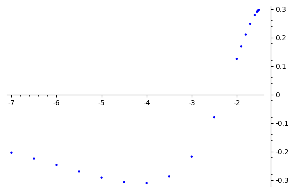

```python
list_plot(plot_data_h_scalar).show()
```

```python
plot_data_h_scalar = []
plot_data_h_scalar_t = []
plot_data_h_scalar_s = []

Ra = Rj1
for dz in (0.01, 0.02, 0.03, 0.04, 0.05, 0.1, 0.2, 0.3, 0.4, 0.5, 1.0, 1.5, 2.0, 2.5, 3.0, 3.5, 4.0, 4.5, 5.0, 5.5):
    Za = Zj1 - dz
    h_scalar = calc_H_scalar(Za, Ra)
    plot_data_h_scalar += [(Za, h_scalar[0])]
    plot_data_h_scalar_t += [(Za, h_scalar[1])]
    plot_data_h_scalar_s += [(Za, h_scalar[2])]
```

```
Ra = 0.300000000000000 Za = -1.51000000000000 H_scalar_t = -26.31408976560741
Ra = 0.300000000000000 Za = -1.51000000000000 H_scalar_s = 15.769056689146678
Ra = 0.300000000000000 Za = -1.51000000000000 H_scalar   = -10.545033076460731
Ra = 0.300000000000000 Za = -1.52000000000000 H_scalar_t = -24.84250417768748
Ra = 0.300000000000000 Za = -1.52000000000000 H_scalar_s = 14.284217820005328
Ra = 0.300000000000000 Za = -1.52000000000000 H_scalar   = -10.558286357682153
Ra = 0.300000000000000 Za = -1.53000000000000 H_scalar_t = -23.94594716753727
Ra = 0.300000000000000 Za = -1.53000000000000 H_scalar_s = 13.376748621678889
Ra = 0.300000000000000 Za = -1.53000000000000 H_scalar   = -10.56919854585838
Ra = 0.300000000000000 Za = -1.54000000000000 H_scalar_t = -23.28473479088355
Ra = 0.300000000000000 Za = -1.54000000000000 H_scalar_s = 12.706592650797099
Ra = 0.300000000000000 Za = -1.54000000000000 H_scalar   = -10.578142140086452
Ra = 0.300000000000000 Za = -1.55000000000000 H_scalar_t = -22.75245647015484
Ra = 0.300000000000000 Za = -1.55000000000000 H_scalar_s = 12.167101836433362
Ra = 0.300000000000000 Za = -1.55000000000000 H_scalar   = -10.585354633721478
Ra = 0.300000000000000 Za = -1.60000000000000 H_scalar_t = -20.93578810516285
Ra = 0.300000000000000 Za = -1.60000000000000 H_scalar_s = 10.335704979605712
Ra = 0.300000000000000 Za = -1.60000000000000 H_scalar   = -10.600083125557138
Ra = 0.300000000000000 Za = -1.70000000000000 H_scalar_t = -18.69736723508141
Ra = 0.300000000000000 Za = -1.70000000000000 H_scalar_s = 8.151431111764246
Ra = 0.300000000000000 Za = -1.70000000000000 H_scalar   = -10.545936123317162
Ra = 0.300000000000000 Za = -1.80000000000000 H_scalar_t = -17.05800419040798
Ra = 0.300000000000000 Za = -1.80000000000000 H_scalar_s = 6.658035211422397
Ra = 0.300000000000000 Za = -1.80000000000000 H_scalar   = -10.399968978985584
Ra = 0.300000000000000 Za = -1.90000000000000 H_scalar_t = -15.68715433125465
Ra = 0.300000000000000 Za = -1.90000000000000 H_scalar_s = 5.510834660503673
Ra = 0.300000000000000 Za = -1.90000000000000 H_scalar   = -10.176319670750978
Ra = 0.300000000000000 Za = -2.00000000000000 H_scalar_t = -14.48531495375845
Ra = 0.300000000000000 Za = -2.00000000000000 H_scalar_s = 4.5952313150709445
Ra = 0.300000000000000 Za = -2.00000000000000 H_scalar   = -9.890083638687507
Ra = 0.300000000000000 Za = -2.50000000000000 H_scalar_t = -10.03018940895463
Ra = 0.300000000000000 Za = -2.50000000000000 H_scalar_s = 1.990470587036009
Ra = 0.300000000000000 Za = -2.50000000000000 H_scalar   = -8.03971882191862
Ra = 0.300000000000000 Za = -3.00000000000000 H_scalar_t = -7.234051656388436
Ra = 0.300000000000000 Za = -3.00000000000000 H_scalar_s = 0.9571609584536631
Ra = 0.300000000000000 Za = -3.00000000000000 H_scalar   = -6.276890697934773
Ra = 0.300000000000000 Za = -3.50000000000000 H_scalar_t = -5.415491646440955
Ra = 0.300000000000000 Za = -3.50000000000000 H_scalar_s = 0.505532006333459
Ra = 0.300000000000000 Za = -3.50000000000000 H_scalar   = -4.9099596401074965
Ra = 0.300000000000000 Za = -4.00000000000000 H_scalar_t = -4.187099950674823
Ra = 0.300000000000000 Za = -4.00000000000000 H_scalar_s = 0.28904659682007505
Ra = 0.300000000000000 Za = -4.00000000000000 H_scalar   = -3.898053353854748
Ra = 0.300000000000000 Za = -4.50000000000000 H_scalar_t = -3.326163062170953
Ra = 0.300000000000000 Za = -4.50000000000000 H_scalar_s = 0.17637443009183873
Ra = 0.300000000000000 Za = -4.50000000000000 H_scalar   = -3.1497886320791144
Ra = 0.300000000000000 Za = -5.00000000000000 H_scalar_t = -2.702483543191398
Ra = 0.300000000000000 Za = -5.00000000000000 H_scalar_s = 0.11348190431357907
Ra = 0.300000000000000 Za = -5.00000000000000 H_scalar   = -2.5890016388778188
Ra = 0.300000000000000 Za = -5.50000000000000 H_scalar_t = -2.237521597678333
Ra = 0.300000000000000 Za = -5.50000000000000 H_scalar_s = 0.07625931712840694
Ra = 0.300000000000000 Za = -5.50000000000000 H_scalar   = -2.161262280549926
Ra = 0.300000000000000 Za = -6.00000000000000 H_scalar_t = -1.882220802712592
Ra = 0.300000000000000 Za = -6.00000000000000 H_scalar_s = 0.053124925183927973
Ra = 0.300000000000000 Za = -6.00000000000000 H_scalar   = -1.829095877528664
Ra = 0.300000000000000 Za = -6.50000000000000 H_scalar_t = -1.604889581886923
Ra = 0.300000000000000 Za = -6.50000000000000 H_scalar_s = 0.038143165675565305
Ra = 0.300000000000000 Za = -6.50000000000000 H_scalar   = -1.5667464162113578
Ra = 0.300000000000000 Za = -7.00000000000000 H_scalar_t = -1.384409350824197
Ra = 0.300000000000000 Za = -7.00000000000000 H_scalar_s = 0.028097004976270767
Ra = 0.300000000000000 Za = -7.00000000000000 H_scalar   = -1.3563123458479263
```

Результирующий график scalar магнитного поля $H_{||}$ на расстоянии Ra = 0.3 см от оси цилиндрической системы координат в зависимости от координаты точки наблюдения $Z_a$

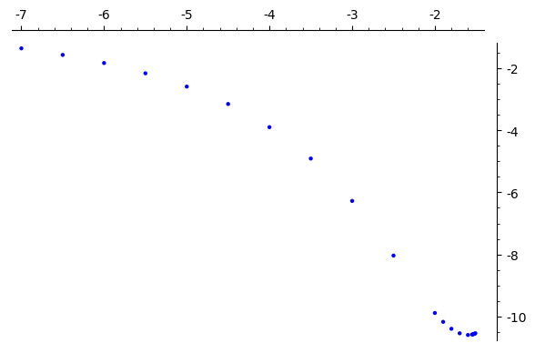

```python
list_plot(plot_data_h_scalar).show()
```

```python
plot_data_h_scalar = []
plot_data_h_scalar_t = []
plot_data_h_scalar_s = []

Ra = (Rj1 + Rj2) / 2
for dz in (0.01, 0.02, 0.03, 0.04, 0.05, 0.1, 0.2, 0.3, 0.4, 0.5, 1.0, 1.5, 2.0, 2.5, 3.0, 3.5, 4.0, 4.5, 5.0, 5.5):
    Za = Zj1 - dz
    h_scalar = calc_H_scalar(Za, Ra)
    plot_data_h_scalar += [(Za, h_scalar[0])]
    plot_data_h_scalar_t += [(Za, h_scalar[1])]
    plot_data_h_scalar_s += [(Za, h_scalar[2])]
```

```
Ra = 0.900000000000000 Za = -1.51000000000000 H_scalar_t = -5.039118110155604
Ra = 0.900000000000000 Za = -1.51000000000000 H_scalar_s = 4.40002506170906
Ra = 0.900000000000000 Za = -1.51000000000000 H_scalar   = -0.6390930484465436
Ra = 0.900000000000000 Za = -1.52000000000000 H_scalar_t = -4.976267956685291
Ra = 0.900000000000000 Za = -1.52000000000000 H_scalar_s = 4.332930231634462
Ra = 0.900000000000000 Za = -1.52000000000000 H_scalar   = -0.643337725050829
Ra = 0.900000000000000 Za = -1.53000000000000 H_scalar_t = -4.914521857479754
Ra = 0.900000000000000 Za = -1.53000000000000 H_scalar_s = 4.266757809867732
Ra = 0.900000000000000 Za = -1.53000000000000 H_scalar   = -0.6477640476120214
Ra = 0.900000000000000 Za = -1.54000000000000 H_scalar_t = -4.853877202156959
Ra = 0.900000000000000 Za = -1.54000000000000 H_scalar_s = 4.201513638654337
Ra = 0.900000000000000 Za = -1.54000000000000 H_scalar   = -0.6523635635026226
Ra = 0.900000000000000 Za = -1.55000000000000 H_scalar_t = -4.794330303104919
Ra = 0.900000000000000 Za = -1.55000000000000 H_scalar_s = 4.13720239156229
Ra = 0.900000000000000 Za = -1.55000000000000 H_scalar   = -0.657127911542629
Ra = 0.900000000000000 Za = -1.60000000000000 H_scalar_t = -4.512860292842516
Ra = 0.900000000000000 Za = -1.60000000000000 H_scalar_s = 3.8297234304358985
Ra = 0.900000000000000 Za = -1.60000000000000 H_scalar   = -0.6831368624066179
Ra = 0.900000000000000 Za = -1.70000000000000 H_scalar_t = -4.027372803029071
Ra = 0.900000000000000 Za = -1.70000000000000 H_scalar_s = 3.28432586622197
Ra = 0.900000000000000 Za = -1.70000000000000 H_scalar   = -0.7430469368071013
Ra = 0.900000000000000 Za = -1.80000000000000 H_scalar_t = -3.633437820542107
Ra = 0.900000000000000 Za = -1.80000000000000 H_scalar_s = 2.8254969645683907
Ra = 0.900000000000000 Za = -1.80000000000000 H_scalar   = -0.8079408559737162
Ra = 0.900000000000000 Za = -1.90000000000000 H_scalar_t = -3.314159456178858
Ra = 0.900000000000000 Za = -1.90000000000000 H_scalar_s = 2.441605549888431
Ra = 0.900000000000000 Za = -1.90000000000000 H_scalar   = -0.8725539062904271
Ra = 0.900000000000000 Za = -2.00000000000000 H_scalar_t = -3.05297901556859
Ra = 0.900000000000000 Za = -2.00000000000000 H_scalar_s = 2.1198480801486506
Ra = 0.900000000000000 Za = -2.00000000000000 H_scalar   = -0.9331309354199395
Ra = 0.900000000000000 Za = -2.50000000000000 H_scalar_t = -2.228334406332435
Ra = 0.900000000000000 Za = -2.50000000000000 H_scalar_s = 1.1073271386797465
Ra = 0.900000000000000 Za = -2.50000000000000 H_scalar   = -1.1210072676526885
Ra = 0.900000000000000 Za = -3.00000000000000 H_scalar_t = -1.745336158278738
Ra = 0.900000000000000 Za = -3.00000000000000 H_scalar_s = 0.6181840834439862
Ra = 0.900000000000000 Za = -3.00000000000000 H_scalar   = -1.1271520748347517
Ra = 0.900000000000000 Za = -3.50000000000000 H_scalar_t = -1.401531643647181
Ra = 0.900000000000000 Za = -3.50000000000000 H_scalar_s = 0.3636858232682727
Ra = 0.900000000000000 Za = -3.50000000000000 H_scalar   = -1.0378458203789083
Ra = 0.900000000000000 Za = -4.00000000000000 H_scalar_t = -1.142837817399087
Ra = 0.900000000000000 Za = -4.00000000000000 H_scalar_s = 0.22440044201275833
Ra = 0.900000000000000 Za = -4.00000000000000 H_scalar   = -0.9184373753863286
Ra = 0.900000000000000 Za = -4.50000000000000 H_scalar_t = -0.9444196938191235
Ra = 0.900000000000000 Za = -4.50000000000000 H_scalar_s = 0.14454623109040843
Ra = 0.900000000000000 Za = -4.50000000000000 H_scalar   = -0.7998734627287151
Ra = 0.900000000000000 Za = -5.00000000000000 H_scalar_t = -0.7902935620355982
Ra = 0.900000000000000 Za = -5.00000000000000 H_scalar_s = 0.09672072680915889
Ra = 0.900000000000000 Za = -5.00000000000000 H_scalar   = -0.6935728352264393
Ra = 0.900000000000000 Za = -5.50000000000000 H_scalar_t = -0.6691038081466925
Ra = 0.900000000000000 Za = -5.50000000000000 H_scalar_s = 0.06690768011420989
Ra = 0.900000000000000 Za = -5.50000000000000 H_scalar   = -0.6021961280324826
Ra = 0.900000000000000 Za = -6.00000000000000 H_scalar_t = -0.5726293984406131
Ra = 0.900000000000000 Za = -6.00000000000000 H_scalar_s = 0.047642845647701826
Ra = 0.900000000000000 Za = -6.00000000000000 H_scalar   = -0.5249865527929113
Ra = 0.900000000000000 Za = -6.50000000000000 H_scalar_t = -0.4948911568050329
Ra = 0.900000000000000 Za = -6.50000000000000 H_scalar_s = 0.03479019917847692
Ra = 0.900000000000000 Za = -6.50000000000000 H_scalar   = -0.46010095762655595
Ra = 0.900000000000000 Za = -7.00000000000000 H_scalar_t = -0.4315170701473746
Ra = 0.900000000000000 Za = -7.00000000000000 H_scalar_s = 0.02596980972223195
Ra = 0.900000000000000 Za = -7.00000000000000 H_scalar   = -0.40554726042514266
```

Результирующий график scalar магнитного поля $H_{||}$ на расстоянии Ra = 0.9 см от оси цилиндрической системы координат в зависимости от координаты точки наблюдения $Z_a$

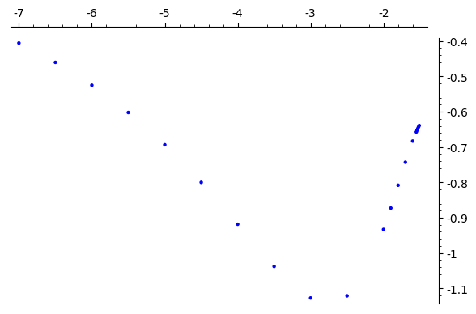

```python
list_plot(plot_data_h_scalar).show()
```

Определяем функцию расчёта поперечной силы Лоренца (компонента $z$), действующей на торец другого цилиндра с координатой $Z_a$ удельная плотность силы Лоренца $$f=\frac{1}{c}[j \times H]$$ поскольку в образовании результирующей силы участвуют только торцевые токи, берём поверхностный интеграл по площади поверхности торца $$F=\frac{1}{c}\int\limits_{S_a}[j_t \times H]\,d{S_a}$$ в цилиндрической системе координат интеграл по площади торца $$F=\frac{1}{c}\int\limits_{r_{a1}}^{r_{a2}}\int\limits_{0}^{2\pi}[j_t \times H]\,r_a\,d{\varphi_a}\,d{r_a}$$ упрощая $$F=\frac{2\pi}{c}\int\limits_{r_{a1}}^{r_{a2}}\,j_t\, H_{\varphi}\,r_a\,d{r_a}$$

```python
def calc_F_lorenz( At_diff_za_subs_zj, As_diff_ra_subs_rj, Za, Ra1, Ra2):
    At_diff_za_subs_zj_za = lambda rj, ra : At_diff_za_subs_zj(rj, ra, Za)
    As_diff_ra_subs_rj_za = lambda ra, zj : As_diff_ra_subs_rj(ra, zj, Za)
    Av_diff_ra_subs_rj_za = lambda ra, zj : Av_diff_ra_subs_rj(ra, zj, Za)

    jt_c = (jt/c).substitute(I0 == 1)

    At_diff_za_num_int_ra = lambda Rj : num_int(lambda ra : (2*pi*jt_c*ra*At_diff_za_subs_zj_za(Rj, ra)), Ra1, Ra2)
    At_diff_za_num_int_ra_int_rj = num_int(lambda rj : At_diff_za_num_int_ra(rj), Rj1, Rj2)

    As_diff_ra_num_int_ra = lambda Zj : num_int(lambda ra : (2*pi*jt_c*ra*(As_diff_ra_subs_rj_za(ra, Zj) ) ), Ra1, Ra2)
    As_diff_ra_num_int_ra_int_zj = num_int(lambda zj : As_diff_ra_num_int_ra(zj), Zj1, Zj2)

    Av_diff_ra_num_int_ra = lambda Zj : num_int(lambda ra : (2*pi*jt_c*ra*(Av_diff_ra_subs_rj_za(ra, Zj) ) ), Ra1, Ra2)
    Av_diff_ra_num_int_ra_int_zj = num_int(lambda zj : Av_diff_ra_num_int_ra(zj), Zj1, Zj2)

    F_z_t = At_diff_za_num_int_ra_int_rj
    F_z_s = As_diff_ra_num_int_ra_int_zj
    F_z_v = Av_diff_ra_num_int_ra_int_zj

    As_v_diff_ra_num_int_ra_int_zj = As_diff_ra_num_int_ra_int_zj + Av_diff_ra_num_int_ra_int_zj
    F_z_sv = - As_v_diff_ra_num_int_ra_int_zj
    F_z = F_z_t + F_z_sv

    print ("Ra1 =", Ra1, "Ra2 =", Ra2, "Za =", Za, "F_z_t  =", F_z_t)
    print ("Ra1 =", Ra1, "Ra2 =", Ra2, "Za =", Za, "F_z_s  =", F_z_s)
    print ("Ra1 =", Ra1, "Ra2 =", Ra2, "Za =", Za, "F_z_v  =", F_z_v)
    print ("Ra1 =", Ra1, "Ra2 =", Ra2, "Za =", Za, "F_z_sv =", F_z_sv)
    print ("Ra1 =", Ra1, "Ra2 =", Ra2, "Za =", Za, "F_z    =", F_z)

    return (F_z, F_z_t, F_z_s, F_z_v)
```

Определяем функцию расчёта поперечной Лоренца (компонента $z$), действующей на левый цилиндр исходя из величины зазора $dz$

```python
def calc_F_lorenz_cylinder(dz):
    # расчет силы Лоренца, действующей на ближайжий (правый) торец пробного цилиндра расположенного левее на расстоянии
    Za = Zj1 - dz
    F_lorenz_left_cylinder_right_t = calc_F_lorenz( At_diff_za_subs_zj, As_diff_ra_subs_rj, Za, Ra1, Ra2)
    print ("Za = ", Za, "F_lorenz_left_cylinder_right_t = ", F_lorenz_left_cylinder_right_t)

    # расчет силы Лоренца, действующей на удалённый (левый) торец пробного цилиндра расположенного левее на расстоянии
    Za = Zj1 - DZ - dz
    F_lorenz_left_cylinder_left_t = calc_F_lorenz( At_diff_za_subs_zj, As_diff_ra_subs_rj, Za, Ra1, Ra2)
    print ("Za = ", Za, "F_lorenz_left_cylinder_left_t =", F_lorenz_left_cylinder_left_t)

    # учитывая отрицательное направление торцевого тока в правом торце и положительное направление торцевого тока в левом торце
    # находим суммарную силу Лоренца действующую на левый цилиндр
    F_lorenz_cylinder = - F_lorenz_left_cylinder_right_t[0] + F_lorenz_left_cylinder_left_t[0]
    print ("dz = ", dz, "F_lorenz_cylinder = ", F_lorenz_cylinder)

    return F_lorenz_cylinder
```

Определяем функцию расчёта силы Николаева (компонента $z$), действующей на surface другого цилиндра с координатой $R_a$ удельная плотность силы Николаева $$f=\frac{1}{c}\left(j \, H_{||}\right)$$ поскольку в образовании результирующей силы участвуют только surface токи, берём поверхностный интеграл по площади поверхности surface $$F=\frac{1}{c}\int\limits_{S_a}\left(j \, H_{||}\right)\,d{S_a}$$ в цилиндрической системе координат интеграл по площади surface $$F=\frac{1}{c}\int\limits_{z_{a1}}^{z_{a2}}\int\limits_{0}^{2\pi}\left(j \, H_{||}\right)\,R_a\,d{\varphi_a}\,d{z_a}$$ упрощая $$F=\frac{2\pi\,R_a}{c}\int\limits_{r_{a1}}^{r_{a2}}\,j_s\, H_{||}\,d{z_a}$$

```python
def calc_F_nikolaev(Ra, Za1, Za2):

    At_ra_diff_ra_div_ra_subs_zj_ra = lambda rj, za : At_ra_diff_ra_div_ra_subs_zj(rj, Ra, za)
    As_diff_za_subs_rj_ra = lambda zj, za : As_diff_za_subs_rj(Ra, zj, za)
    Av_diff_za_subs_rj_ra = lambda zj, za : Av_diff_za_subs_rj(Ra, zj, za)

    jt_c = (jt/c).substitute(I0 == 1)

    At_diff_ra_num_int_ra = lambda Rj : num_int(lambda za : (2*pi*jt_c*Ra*At_ra_diff_ra_div_ra_subs_zj_ra(Rj, za)), Za1, Za2)
    At_diff_ra_num_int_ra_int_rj = num_int(lambda rj : At_diff_ra_num_int_ra(rj), Rj1, Rj2)

    As_diff_za_num_int_ra = lambda Zj : num_int(lambda za : (2*pi*jt_c*Ra*(As_diff_za_subs_rj_ra(Zj, za) ) ), Za1, Za2)
    As_diff_za_num_int_ra_int_zj = num_int(lambda zj : As_diff_za_num_int_ra(zj), Zj1, Zj2)

    Av_diff_za_num_int_ra = lambda Zj : num_int(lambda za : (2*pi*jt_c*Ra*(Av_diff_za_subs_rj_ra(Zj, za) ) ), Za1, Za2)
    Av_diff_za_num_int_ra_int_zj = num_int(lambda zj : Av_diff_za_num_int_ra(zj), Zj1, Zj2)


    F_z_t = - At_diff_ra_num_int_ra_int_rj
    F_z_s = - As_diff_za_num_int_ra_int_zj
    F_z_v = - Av_diff_za_num_int_ra_int_zj

    As_v_diff_za_num_int_ra_int_zj = As_diff_za_num_int_ra_int_zj + Av_diff_za_num_int_ra_int_zj
    F_z_sv = - As_v_diff_za_num_int_ra_int_zj
    F_z = F_z_t + F_z_sv

    print ("Ra1 =", Ra1, "Ra2 =", Ra2, "Za =", Za, "F_z_t  =", F_z_t)
    print ("Ra1 =", Ra1, "Ra2 =", Ra2, "Za =", Za, "F_z_s  =", F_z_s)
    print ("Ra1 =", Ra1, "Ra2 =", Ra2, "Za =", Za, "F_z_v  =", F_z_v)
    print ("Ra1 =", Ra1, "Ra2 =", Ra2, "Za =", Za, "F_z_sv =", F_z_sv)
    print ("Ra1 =", Ra1, "Ra2 =", Ra2, "Za =", Za, "F_z    =", F_z)

    return (F_z, F_z_t, F_z_s, F_z_v)
```

Определяем функцию расчёта силы Николаева (компонента $z$), действующей на левый цилиндр исходя из величины зазора $dz$

```python
def calc_F_nikolaev_cylinder(dz):
    # расчет силы Nikolaev's, действующей на inner surface пробного цилиндра расположенного левее на расстоянии
    Za1 = Zj1 - dz - DZ
    Za2 = Zj1 - dz
    Ra = Rj1
    F_nikolaev_left_cylinder_inner_s = calc_F_nikolaev(Ra, Za1, Za2)
    print ("Ra = ", Ra, "F_nikolaev_left_cylinder_inner_s = ", F_nikolaev_left_cylinder_inner_s)

    # расчет силы Лоренца, действующей на outer surface пробного цилиндра расположенного левее на расстоянии
    Ra =  Rj2
    F_nikolaev_left_cylinder_outer_s = calc_F_nikolaev(Ra, Za1, Za2)
    print ("Ra = ", Ra, "F_nikolaev_left_cylinder_outer_s =", F_nikolaev_left_cylinder_outer_s)

    # учитывая отрицательное направление торцевого тока на inner surface и положительное направление торцевого тока на outer surface
    # находим суммарную силу Лоренца действующую на левый цилиндр
    F_nikolaev_cylinder = - F_nikolaev_left_cylinder_inner_s[0] + F_nikolaev_left_cylinder_outer_s[0]
    print ("dz = ", dz, "F_nikolaev_cylinder = ", F_nikolaev_cylinder)

    return F_nikolaev_cylinder
```

Запуск расчёта силы Лоренца и величины векторного магнитного поля для заданного набора значений зазора между цилиндрами

```python
plot_data_f_lorenz_dz = []
plot_data_f_lorenz_Za = []
plot_data_f_nikolaev_dz = []
plot_data_f_nikolaev_Za = []
plot_data_f_sum_dz = []
plot_data_f_sum_Za = []
plot_data_h = []
plot_data_h_t = []
plot_data_h_s = []

Ra = (Rj1 + Rj2) / 2
for dz in (0.01, 0.02, 0.03, 0.04, 0.05, 0.1, 0.2, 0.3, 0.4, 0.5, 1.0, 1.5, 2.0):
    Za = Zj1 - dz
    h = calc_H_phi( At_diff_za_subs_zj, As_diff_ra_subs_rj, Za, Ra)
    f_nikolaev = calc_F_nikolaev_cylinder(dz)
    f_lorenz = calc_F_lorenz_cylinder(dz)
    plot_data_h += [(Za, h[0])]
    plot_data_h_t += [(Za, h[1])]
    plot_data_h_s += [(Za, h[2])]
    plot_data_f_lorenz_dz += [(dz, f_lorenz)]
    plot_data_f_lorenz_Za += [(Za, f_lorenz)]
    plot_data_f_nikolaev_dz += [(dz, f_nikolaev)]
    plot_data_f_nikolaev_Za += [(Za, f_nikolaev)]
    plot_data_f_sum_dz += [(dz, f_lorenz + f_nikolaev)]
    plot_data_f_sum_Za += [(Za, f_lorenz + f_nikolaev)]
```

```
Ra = 0.900000000000000 Za = -1.51000000000000 H_phi_t = 5.644078024649912
Ra = 0.900000000000000 Za = -1.51000000000000 H_phi_s = -6.112910411879253
Ra = 0.900000000000000 Za = -1.51000000000000 H_phi   = -0.46883238722934095
Ra1 = 0.300000000000000 Ra2 = 1.50000000000000 Za = -1.51000000000000 F_z_t  = -50.27132562084646
Ra1 = 0.300000000000000 Ra2 = 1.50000000000000 Za = -1.51000000000000 F_z_s  = -6.105407607069458
Ra1 = 0.300000000000000 Ra2 = 1.50000000000000 Za = -1.51000000000000 F_z_v  = 18.855251315045734
Ra1 = 0.300000000000000 Ra2 = 1.50000000000000 Za = -1.51000000000000 F_z_sv = 12.749843707976275
Ra1 = 0.300000000000000 Ra2 = 1.50000000000000 Za = -1.51000000000000 F_z    = -37.521481912870186
Ra =  0.300000000000000 F_nikolaev_left_cylinder_inner_s =  (-37.521481912870186, -50.27132562084646, -6.105407607069458, 18.855251315045734)
Ra1 = 0.300000000000000 Ra2 = 1.50000000000000 Za = -1.51000000000000 F_z_t  = -0.4012561278347424
Ra1 = 0.300000000000000 Ra2 = 1.50000000000000 Za = -1.51000000000000 F_z_s  = -61.539116398536116
Ra1 = 0.300000000000000 Ra2 = 1.50000000000000 Za = -1.51000000000000 F_z_v  = 58.19976143360743
Ra1 = 0.300000000000000 Ra2 = 1.50000000000000 Za = -1.51000000000000 F_z_sv = -3.339354964928688
Ra1 = 0.300000000000000 Ra2 = 1.50000000000000 Za = -1.51000000000000 F_z    = -3.7406110927634306
Ra =  1.50000000000000 F_nikolaev_left_cylinder_outer_s = (-3.7406110927634306, -0.4012561278347424, -61.539116398536116, 58.19976143360743)
dz =  0.0100000000000000 F_nikolaev_cylinder =  33.780870820106756
Ra1 = 0.300000000000000 Ra2 = 1.50000000000000 Za = -1.51000000000000 F_z_t  = 37.574573607478655
Ra1 = 0.300000000000000 Ra2 = 1.50000000000000 Za = -1.51000000000000 F_z_s  = 14.883427043888043
Ra1 = 0.300000000000000 Ra2 = 1.50000000000000 Za = -1.51000000000000 F_z_v  = 25.724906359382704
Ra1 = 0.300000000000000 Ra2 = 1.50000000000000 Za = -1.51000000000000 F_z_sv = -40.60833340327075
Ra1 = 0.300000000000000 Ra2 = 1.50000000000000 Za = -1.51000000000000 F_z    = -3.0337597957920934
Za =  -1.51000000000000 F_lorenz_left_cylinder_right_t =  (-3.0337597957920934, 37.574573607478655, 14.883427043888043, 25.724906359382704)
Ra1 = 0.300000000000000 Ra2 = 1.50000000000000 Za = -4.51000000000000 F_z_t  = 2.6040228344504093
Ra1 = 0.300000000000000 Ra2 = 1.50000000000000 Za = -4.51000000000000 F_z_s  = -1.2057716280010589
Ra1 = 0.300000000000000 Ra2 = 1.50000000000000 Za = -4.51000000000000 F_z_v  = 1.6597835531830494
Ra1 = 0.300000000000000 Ra2 = 1.50000000000000 Za = -4.51000000000000 F_z_sv = -0.4540119251819905
Ra1 = 0.300000000000000 Ra2 = 1.50000000000000 Za = -4.51000000000000 F_z    = 2.1500109092684188
Za =  -4.51000000000000 F_lorenz_left_cylinder_left_t = (2.1500109092684188, 2.6040228344504093, -1.2057716280010589, 1.6597835531830494)
dz =  0.0100000000000000 F_lorenz_cylinder =  5.183770705060512
Ra = 0.900000000000000 Za = -1.52000000000000 H_phi_t = 5.583593170676274
Ra = 0.900000000000000 Za = -1.52000000000000 H_phi_s = -6.014895008192264
Ra = 0.900000000000000 Za = -1.52000000000000 H_phi   = -0.43130183751599027
Ra1 = 0.300000000000000 Ra2 = 1.50000000000000 Za = -1.52000000000000 F_z_t  = -49.852971132802466
Ra1 = 0.300000000000000 Ra2 = 1.50000000000000 Za = -1.52000000000000 F_z_s  = -6.23693560121213
Ra1 = 0.300000000000000 Ra2 = 1.50000000000000 Za = -1.52000000000000 F_z_v  = 18.70831329568085
Ra1 = 0.300000000000000 Ra2 = 1.50000000000000 Za = -1.52000000000000 F_z_sv = 12.47137769446872
Ra1 = 0.300000000000000 Ra2 = 1.50000000000000 Za = -1.52000000000000 F_z    = -37.381593438333745
Ra =  0.300000000000000 F_nikolaev_left_cylinder_inner_s =  (-37.381593438333745, -49.852971132802466, -6.23693560121213, 18.70831329568085)
Ra1 = 0.300000000000000 Ra2 = 1.50000000000000 Za = -1.52000000000000 F_z_t  = -1.0538854962062998
Ra1 = 0.300000000000000 Ra2 = 1.50000000000000 Za = -1.52000000000000 F_z_s  = -60.67140384019121
```

[output cut: 322 more lines]

```
Ra =  1.50000000000000 F_nikolaev_left_cylinder_outer_s = (-7.952309526847772, -10.27863635842033, -22.310423439548465, 24.636750271121024)
dz =  2.00000000000000 F_nikolaev_cylinder =  7.869352397806013
Ra1 = 0.300000000000000 Ra2 = 1.50000000000000 Za = -3.50000000000000 F_z_t  = 5.0433466641048765
Ra1 = 0.300000000000000 Ra2 = 1.50000000000000 Za = -3.50000000000000 F_z_s  = -1.9181700227534269
Ra1 = 0.300000000000000 Ra2 = 1.50000000000000 Za = -3.50000000000000 F_z_v  = 3.4031628639664406
Ra1 = 0.300000000000000 Ra2 = 1.50000000000000 Za = -3.50000000000000 F_z_sv = -1.4849928412130138
Ra1 = 0.300000000000000 Ra2 = 1.50000000000000 Za = -3.50000000000000 F_z    = 3.5583538228918625
Za =  -3.50000000000000 F_lorenz_left_cylinder_right_t =  (3.5583538228918625, 5.0433466641048765, -1.9181700227534269, 3.4031628639664406)
Ra1 = 0.300000000000000 Ra2 = 1.50000000000000 Za = -6.50000000000000 F_z_t  = 0.9412981201938949
Ra1 = 0.300000000000000 Ra2 = 1.50000000000000 Za = -6.50000000000000 F_z_s  = -0.4931058316639564
Ra1 = 0.300000000000000 Ra2 = 1.50000000000000 Za = -6.50000000000000 F_z_v  = 0.569243968725318
Ra1 = 0.300000000000000 Ra2 = 1.50000000000000 Za = -6.50000000000000 F_z_sv = -0.07613813706136163
Ra1 = 0.300000000000000 Ra2 = 1.50000000000000 Za = -6.50000000000000 F_z    = 0.8651599831325333
Za =  -6.50000000000000 F_lorenz_left_cylinder_left_t = (0.8651599831325333, 0.9412981201938949, -0.4931058316639564, 0.569243968725318)
dz =  2.00000000000000 F_lorenz_cylinder =  -2.693193839759329
```

```python
Ra = (Rj1 + Rj2) / 2
Za = 0
h = calc_H_phi( At_diff_za_subs_zj, As_diff_ra_subs_rj, Za, Ra)
```

```
Ra = 0.900000000000000 Za = 0 H_phi_t = -2.946214132385315
Ra = 0.900000000000000 Za = 0 H_phi_s = nan
Ra = 0.900000000000000 Za = 0 H_phi   = nan
```

```python
dr = 0.01
dz = 0.04
Za = 0
for Ra in(Rj1 - dr, Rj1 + dr, (Rj1 + Rj2)/2, Rj2 - dr, Rj2 + dr, 2 * Rj2, 10 * Rj2):
    h = calc_H_phi( At_diff_za_subs_zj, As_diff_ra_subs_rj, Za, Ra)
```

```
Ra = 0.290000000000000 Za = 0 H_phi_t = -3.386747752030594
Ra = 0.290000000000000 Za = 0 H_phi_s = 0.40678948583773067
Ra = 0.290000000000000 Za = 0 H_phi   = -2.979958266192863
```

```
Ra = 0.310000000000000 Za = 0 H_phi_t = -3.379589544369999
Ra = 0.310000000000000 Za = 0 H_phi_s = -12.133552134121588
Ra = 0.310000000000000 Za = 0 H_phi   = -15.513141678491587
```

```
Ra = 0.900000000000000 Za = 0 H_phi_t = -2.946214132385315
Ra = 0.900000000000000 Za = 0 H_phi_s = nan
Ra = 0.900000000000000 Za = 0 H_phi   = nan
Ra = 1.49000000000000 Za = 0 H_phi_t = -2.170556321566785
Ra = 1.49000000000000 Za = 0 H_phi_s = -11.649582641603057
Ra = 1.49000000000000 Za = 0 H_phi   = -13.820138963169843
Ra = 1.51000000000000 Za = 0 H_phi_t = -2.141833989457342
Ra = 1.51000000000000 Za = 0 H_phi_s = 0.9084390627924321
Ra = 1.51000000000000 Za = 0 H_phi   = -1.2333949266649098
Ra = 3.00000000000000 Za = 0 H_phi_t = -0.6289858191740627
Ra = 3.00000000000000 Za = 0 H_phi_s = 0.2500486265121036
Ra = 3.00000000000000 Za = 0 H_phi   = -0.37893719266195913
Ra = 15.0000000000000 Za = 0 H_phi_t = -0.006010885960632351
Ra = 15.0000000000000 Za = 0 H_phi_s = 0.0006147120531279915
Ra = 15.0000000000000 Za = 0 H_phi   = -0.00539617390750436
```

```python
#list_plot(plot_data_f_lorenz_dz).show()
```

Результирующий график силы Лоренца приложенной к левому цилиндру в зависимости от координаты правого торца левого цилиндра

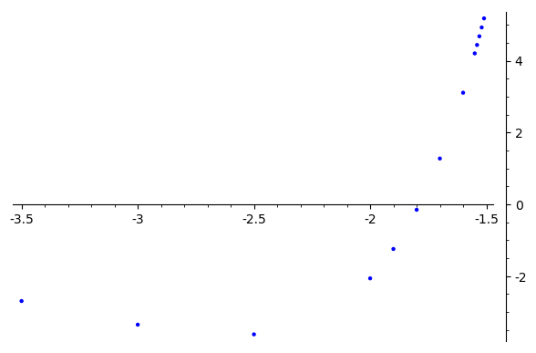

```python
list_plot(plot_data_f_lorenz_Za).show()
```

```python
#list_plot(plot_data_f_nikolaev_dz).show()
```

Результирующий график силы Николаева приложенной к левому цилиндру в зависимости от координаты правого торца левого цилиндра

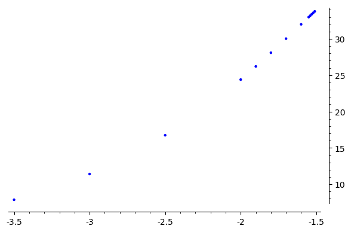

```python
list_plot(plot_data_f_nikolaev_Za).show()
```

Результирующий график силы Николаева + силы Лоренца приложенной к левому цилиндру в зависимости от координаты правого торца левого цилиндра

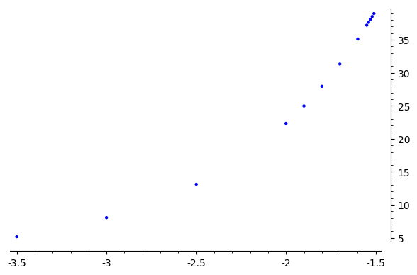

```python
list_plot(plot_data_f_sum_Za).show()
```

Результаты расчёта силы притяжения между тороидально намагниченными цилиндрами в зависимости от зазора позволяют сделать вывод о том, что поперечная сила Ампера-Лоренца при величине зазора меньше определённого предела работает на притяжение цилиндров, которое собственно и зафиксировано в опыте. При величине зазора больше определённого предела поперечная сила Ампера-Лоренца работает на отталкивание цилиндров.

Этот момент в опыте Дейны зафиксирован не был, ввиду того, что при планировании эксперимента вопрос о зависимости направления силы взаимодействия от зазора между цилиндрами не ставился.

На взгляд автора для дальнейших исследований необходима следующая постановка эксперимента. Установить зазор между цилиндрами более 3 мм. И показать направление силы их взаимодействия: притягивание или отталкивание.

Таким образом в данной работе показано, что для доказательства существования продольной силы Николаева с помощью опыта Дейны (опыт Николаева 31) совершенно недостаточно установления факта притяжения цилиндров при зазоре между их торцами менее 3 мм. Для выяснения этого вопроса необходимы дальнейшие экспериментальные исследования.

# К вопросу о теореме циркуляции магнитного поля в плоскости вне материала тороидально намагниченного цилиндра

Результирующий график векторного магнитного поля $H$ (компонента $\varphi$) на расстоянии Ra = 0.9 см от оси цилиндрической системы координат в зависимости от координаты точки наблюдения $Z_a$

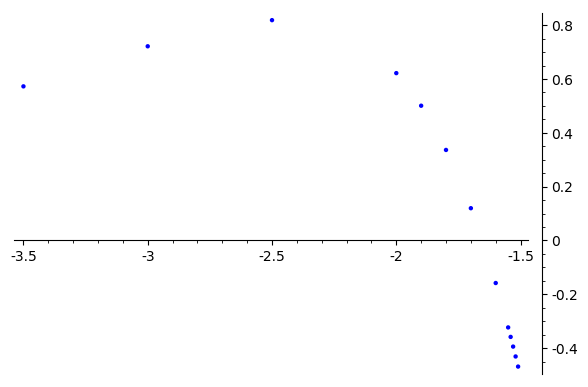

```python
list_plot(plot_data_h).show()
```

Может показаться, что полученные в данной работе результаты о налиции угловой компоненты векторного магнитного поля за пределами материала тороидально намагниченного цилиндра противоречат теореме о циркуляции магнитного поля.

$\oint {\vec B}\cdot {\vec {dl}}={\frac {4\pi }{c}}\int {\vec j}\cdot {\vec {ds}}$

Действительно, циркуляция магнитного поля взятая по окружности отстоящей на некотором расстоянии от торца тороидально намагниченного цилиндра отлична от нуля, в то время как молекулярные токи намагниченности не пересекают плоскость, натянутую на эту окружность.

Это кажущееся противоречие разрешается тем, что данную плоскость пересекают токи смещения продуцированные молекулярными токами намагниченности цилиндра.

Исходя из определения ротора в цилиндрических координатах и того факта что в данной конфигурации отлична от нуля только $H_{\varphi}$ компонента магнитного поля для ротора $H$ будут отличными от нуля следующие две компоненты

$rot\,H_r = -\frac{\partial}{\partial z_a}H_{\varphi}$

$rot\,H_z = \frac{1}{r_a}\frac{\partial}{\partial r_a}(r_a\,H_{\varphi})$

где

$H_{\varphi}=\frac{\partial}{\partial z_a}A_T - \frac{\partial}{\partial r_a}(A_S+A_V)$

Итак,

$rot\,H_r = -\frac{\partial}{\partial z_a}\frac{\partial}{\partial z_a}A_T+\frac{\partial}{\partial z_a}\frac{\partial}{\partial r_a}(A_S+A_V)$

$rot\,H_z = \frac{1}{r_a}\frac{\partial}{\partial r_a}(r_a\,\frac{\partial}{\partial z_a}A_T)-\frac{1}{r_a}\frac{\partial}{\partial r_a}(r_a\,\frac{\partial}{\partial r_a}(A_S+A_V))$

```python
At2_diff_za_mult_ra_diff_ra_div_ra = lambda I0, rj, ra, zj1, zj2, za : (1/ra)*(ra*At2_diff_za (I0, rj, ra, zj1, zj2, za)).diff(ra)
print(At2_diff_za_mult_ra_diff_ra_div_ra (I0, rj, ra, zj1, zj2, za))
```

```
-2*(2*I0*rj*(za - zj1)*elliptic_kc(-4*ra*rj/((ra - rj)^2 + (za - zj1)^2))/((ra - rj)^2 + (za - zj1)^2)^(3/2) - 2*I0*rj*(za - zj2)*elliptic_kc(-4*ra*rj/((ra - rj)^2 + (za - zj2)^2))/((ra - rj)^2 + (za - zj2)^2)^(3/2) - (6*I0*(ra - rj)*rj*(za - zj1)*elliptic_kc(-4*ra*rj/((ra - rj)^2 + (za - zj1)^2))/(…
```

```python
As2_diff_ra_mult_ra_diff_ra_div_ra = lambda I0, rj1, rj2, ra, zj, za : (1/ra)*(ra*As2_diff_ra (I0, rj1, rj2, ra, zj, za)).diff(ra)
print (As2_diff_ra_mult_ra_diff_ra_div_ra (I0, rj1, rj2, ra, zj, za))
```

```
(4*I0*(ra - rj1)*rj1*elliptic_kc(-4*ra*rj1/((ra - rj1)^2 + (za - zj)^2))/((ra - rj1)^2 + (za - zj)^2)^(3/2) - 4*I0*(ra - rj2)*rj2*elliptic_kc(-4*ra*rj2/((ra - rj2)^2 + (za - zj)^2))/((ra - rj2)^2 + (za - zj)^2)^(3/2) - (12*I0*(ra - rj1)^2*rj1*elliptic_kc(-4*ra*rj1/((ra - rj1)^2 + (za - zj)^2))/((ra …
```

```python
exec(preparse("At_diff_za_mult_ra_diff_ra_div_ra_subs_zj = lambda rj, ra, za : " + str(At2_diff_za_mult_ra_diff_ra_div_ra (1, rj, ra, Zj1, Zj2, za))))
# print (At_diff_za_mult_ra_diff_ra_div_ra_subs_zj (rj, ra, za))
```

```python
exec(preparse("As_diff_ra_mult_ra_diff_ra_div_ra_subs_rj = lambda ra, zj, za : " + str(As2_diff_ra_mult_ra_diff_ra_div_ra (1, Rj1, Rj2, ra, zj, za))))
# print (As_diff_ra_mult_ra_diff_ra_div_ra_subs_rj (ra, zj, za))
```

```python
exec(preparse("Av_diff_ra_mult_ra_diff_ra_div_ra = lambda I0, rj, ra, zj, za : " + str((1/ra)*(ra*Av_diff_ra(I0, rj, ra, zj, za)).diff(ra))))
print (Av_diff_ra_mult_ra_diff_ra_div_ra (I0, rj, ra, zj, za))
```

```
-((12*I0*(ra - rj)^2*elliptic_kc(-4*ra*rj/((ra - rj)^2 + (za - zj)^2))/((ra - rj)^2 + (za - zj)^2)^(5/2) - sqrt((ra - rj)^2 + (za - zj)^2)*(8*(2*(ra - rj)*ra*rj/((ra - rj)^2 + (za - zj)^2)^2 - rj/((ra - rj)^2 + (za - zj)^2))*elliptic_kc(-4*ra*rj/((ra - rj)^2 + (za - zj)^2)) - ((ra - rj)^2 + (za - zj…
```

```python
AV_diff_ra_mult_ra_diff_ra_div_ra = lambda I0, rj1, rj2, ra, zj, za : num_int(lambda rj : Av_diff_ra_mult_ra_diff_ra_div_ra(I0, rj, ra, zj, za), rj1, rj2)
```

```python
Av_diff_ra_mult_ra_diff_ra_div_ra_subs_rj = lambda ra, zj, za : AV_diff_ra_mult_ra_diff_ra_div_ra (1, Rj1, Rj2, ra, zj, za)
# print (Av_diff_ra_mult_ra_diff_ra_div_ra_subs_rj(ra, zj, za))
```

```python
def calc_rot_H_z(Za, Ra):
    At_diff_za_mult_ra_diff_ra_div_ra_subs_zj_subs_za_ra = lambda rj : At_diff_za_mult_ra_diff_ra_div_ra_subs_zj(rj, Ra, Za)
    As_diff_ra_mult_ra_diff_ra_div_ra_subs_rj_subs_za_ra = lambda zj : As_diff_ra_mult_ra_diff_ra_div_ra_subs_rj(Ra, zj, Za)

    At_diff_za_mult_ra_diff_ra_div_ra_num_int = At_diff_za_mult_ra_diff_ra_div_ra_subs_zj_subs_za_ra(rj).nintegral(rj, Rj1, Rj2)
    As_diff_ra_mult_ra_diff_ra_div_ra_num_int = As_diff_ra_mult_ra_diff_ra_div_ra_subs_rj_subs_za_ra(zj).nintegral(zj, Zj1, Zj2)
    Av_diff_ra_mult_ra_diff_ra_div_ra_num_int = num_int( lambda zj : Av_diff_ra_mult_ra_diff_ra_div_ra_subs_rj(Ra, zj, Za), Zj1, Zj2)
    As_v_diff_ra_mult_ra_diff_ra_div_ra_num_int = As_diff_ra_mult_ra_diff_ra_div_ra_num_int[0] + Av_diff_ra_mult_ra_diff_ra_div_ra_num_int

    rot_H_z = At_diff_za_mult_ra_diff_ra_div_ra_num_int[0] - As_v_diff_ra_mult_ra_diff_ra_div_ra_num_int

    print ("Ra =", Ra, "Za =", Za, "rot_H_z =", rot_H_z)

    return rot_H_z
```

Теорема о циркуляции магнитного поля записывается следующим образом

$\oint {\vec B}\cdot {\vec {dl}}={\frac {4\pi }{c}}\int {\vec j}\cdot {\vec {ds}}$

Вне материала цилиндра ток проводимости (равно как и молекулярный ток намагниченности) равен нулю.

Поэтому единственно возможный вариант в этом случае принять, что циркуляция магнитного поля в плоскости не пересекающей материал тороидально намагниченного цилиндра, обусловлена токами смещения

$\vec{j_{см}} = \frac{c}{4\pi}\, rot\,\vec{H}$

Подставляя данное выражение для тока смещения в теорему о циркуляции приходим к тождеству

$\oint {\vec B}\cdot {\vec {dl}}= \int { rot\,\vec{H}}\cdot {\vec {ds}}$

проверкой которого и займёмся

$2\,\pi\,R_a\,\mu H_z = \int\limits_{0}^{2\pi}\int\limits_{0}^{R_a} r\,rot\,H_z\,{dr}\,{d\varphi}$

$2\,\pi\,R_a\,\mu H_z = 2\,\pi\, \int\limits_{0}^{R_a} r\,rot\,H_z\,{dr}$

```python
dr = 0.01
dz = 0.04
Za = Zj1 - dz
circ_H_J_z = []
for Ra in(Rj1 - dr, Rj1 + dr, (Rj1 + Rj2)/2, Rj2 - dr, Rj2 + dr, 2 * Rj2, 10 * Rj2):
    (H_phi, H_phi_t, H_phi_s) = calc_H_phi( At_diff_za_subs_zj, As_diff_ra_subs_rj, Za, Ra)
    circ_H = 2 * pi * Ra * H_phi
    print ("circ_H (", Ra, ") = ", circ_H)

    J_z = 2 * pi * num_int( lambda ra : ra * calc_rot_H_z(Za, ra), 0, Ra)
    print ("J_z (", Ra, ") = ", J_z)

    circ_H_J_z += [((Ra, Za), (circ_H, J_z))]
```

```
Ra = 0.290000000000000 Za = -1.54000000000000 H_phi_t = 2.419092454177002
Ra = 0.290000000000000 Za = -1.54000000000000 H_phi_s = -2.605503698084907
Ra = 0.290000000000000 Za = -1.54000000000000 H_phi   = -0.1864112439079051
circ_H ( 0.290000000000000 ) =  -0.108118521466585*pi
Ra = 0.145 Za = -1.54000000000000 rot_H_z = -1.5969858479306458
Ra = 0.0037835533650101005 Za = -1.54000000000000 rot_H_z = 8.137642796027171
Ra = 0.2862164466349899 Za = -1.54000000000000 rot_H_z = -0.8108247866716596
Ra = 0.01956581183009723 Za = -1.54000000000000 rot_H_z = -1.1042591522737024
Ra = 0.2704341881699027 Za = -1.54000000000000 rot_H_z = -0.865446189283368
Ra = 0.046485612596641454 Za = -1.54000000000000 rot_H_z = -2.006022142638341
Ra = 0.2435143874033585 Za = -1.54000000000000 rot_H_z = -1.0088663353214713
Ra = 0.08215766785125915 Za = -1.54000000000000 rot_H_z = -1.9701034998938507
Ra = 0.20784233214874082 Za = -1.54000000000000 rot_H_z = -1.2172899723284587
Ra = 0.12341322084766346 Za = -1.54000000000000 rot_H_z = -1.7316005491538893
Ra = 0.16658677915233652 Za = -1.54000000000000 rot_H_z = -1.4640983012759223
Ra = 0.0006297113612578342 Za = -1.54000000000000 rot_H_z = 67.25422999257134
Ra = 0.28937028863874215 Za = -1.54000000000000 rot_H_z = -0.8053777674338818
Ra = 0.010127163753422291 Za = -1.54000000000000 rot_H_z = 0.856679280497544
Ra = 0.27987283624657766 Za = -1.54000000000000 rot_H_z = -0.8279986673618183
Ra = 0.03178142964496955 Za = -1.54000000000000 rot_H_z = -1.781208503565022
Ra = 0.25821857035503043 Za = -1.54000000000000 rot_H_z = -0.9266706516458143
Ra = 0.06340021547305232 Za = -1.54000000000000 rot_H_z = -2.034894124230924
Ra = 0.22659978452694768 Za = -1.54000000000000 rot_H_z = -1.10709593983991
Ra = 0.10231303490828826 Za = -1.54000000000000 rot_H_z = -1.8605203031654343
Ra = 0.18768696509171173 Za = -1.54000000000000 rot_H_z = -1.3368533250897379
Ra = 0.0725 Za = -1.54000000000000 rot_H_z = -2.0106666157080153
Ra = 0.0018917766825050503 Za = -1.54000000000000 rot_H_z = 19.916446094125416
Ra = 0.14310822331749495 Za = -1.54000000000000 rot_H_z = -1.6087470295833954
Ra = 0.009782905915048615 Za = -1.54000000000000 rot_H_z = 1.0056385577888358
Ra = 0.13521709408495136 Za = -1.54000000000000 rot_H_z = -1.6579342808935928
Ra = 0.023242806298320727 Za = -1.54000000000000 rot_H_z = -1.403228613945751
Ra = 0.12175719370167926 Za = -1.54000000000000 rot_H_z = -1.7419058031514063
Ra = 0.041078833925629575 Za = -1.54000000000000 rot_H_z = -1.9577922233784493
Ra = 0.10392116607437041 Za = -1.54000000000000 rot_H_z = -1.8509862492482236
Ra = 0.06170661042383173 Za = -1.54000000000000 rot_H_z = -2.037236175586288
Ra = 0.08329338957616826 Za = -1.54000000000000 rot_H_z = -1.9646451910773974
Ra = 0.0003148556806289171 Za = -1.54000000000000 rot_H_z = 138.24264281768194
Ra = 0.14468514431937107 Za = -1.54000000000000 rot_H_z = -1.5989422838415797
Ra = 0.005063581876711146 Za = -1.54000000000000 rot_H_z = 5.175482049545809
Ra = 0.13993641812328883 Za = -1.54000000000000 rot_H_z = -1.6284962538882732
```

[output cut: 1639 more lines]

```
Ra = 1.5566369886252394 Za = -1.54000000000000 rot_H_z = -0.155518205393129
Ra = 1.6074255113747606 Za = -1.54000000000000 rot_H_z = -0.1319832374270833
Ra = 1.573308144200295 Za = -1.54000000000000 rot_H_z = -0.14717555759952639
Ra = 1.590754355799705 Za = -1.54000000000000 rot_H_z = -0.1391138651545969
Ra = 1.5236919631039565 Za = -1.54000000000000 rot_H_z = -0.17344420346412903
Ra = 1.6403705368960435 Za = -1.54000000000000 rot_H_z = -0.11925678552325403
Ra = 1.5275298344908765 Za = -1.54000000000000 rot_H_z = -0.1713442062018089
Ra = 1.6365326655091235 Za = -1.54000000000000 rot_H_z = -0.1206575525169149
Ra = 1.536280211332827 Za = -1.54000000000000 rot_H_z = -0.1664985451340968
Ra = 1.627782288667173 Za = -1.54000000000000 rot_H_z = -0.12392743128244632
Ra = 1.5490571991405115 Za = -1.54000000000000 rot_H_z = -0.1595193793881151
Ra = 1.6150053008594885 Za = -1.54000000000000 rot_H_z = -0.12890579027280413
Ra = 1.5647816682010862 Za = -1.54000000000000 rot_H_z = -0.1513620729101639
Ra = 1.5992808317989138 Za = -1.54000000000000 rot_H_z = -0.13540184769342734
J_z ( 15.0000000000000 ) =  -0.15495902664807285*pi
```

```python
for (Ra, Za), (circ_H, J_z) in circ_H_J_z:
    print ("Ra=", Ra, "Za=", Za, "circ_H=", circ_H, "J_z=", J_z)
```

```
Ra= 0.290000000000000 Za= -1.54000000000000 circ_H= -0.108118521466585*pi J_z= -0.10811852146666323*pi
Ra= 0.310000000000000 Za= -1.54000000000000 circ_H= -0.117821565803311*pi J_z= -0.11782156580235059*pi
Ra= 0.900000000000000 Za= -1.54000000000000 circ_H= -0.645400681610558*pi J_z= -0.6454006816107795*pi
Ra= 1.49000000000000 Za= -1.54000000000000 circ_H= -1.04545372632752*pi J_z= -1.0454537263294106*pi
Ra= 1.51000000000000 Za= -1.54000000000000 circ_H= -1.05652346264694*pi J_z= -1.0565234626489075*pi
Ra= 3.00000000000000 Za= -1.54000000000000 circ_H= -1.18241457183107*pi J_z= -1.1824145718314787*pi
Ra= 15.0000000000000 Za= -1.54000000000000 circ_H= -0.154959026647993*pi J_z= -0.15495902664807285*pi
```

Итак мы видим, что результат проверки теоремы циркуляции в плоскости, отстоящей на некоторое расстояние от левого торца цилиндра вполне удовлетворителен, что косвенно подтверждает гипотезу о существовании токов смещения вне материала тороидально намагниченного цилиндра

Ниже представлены графики $z$-компоненты плотности тока смещения (исходя из ротора напряженности магнитного поля) вне материала тороидально намагниченного цилиндра в зависимости от $z$ координаты для разных радиальных координат

```
Ra = 0.900000000000000 Za = -1.51000000000000 rot_H_z = -0.4151014901957355
Ra = 0.900000000000000 Za = -1.52000000000000 rot_H_z = -0.4336915558412153
Ra = 0.900000000000000 Za = -1.53000000000000 rot_H_z = -0.45143206514659084
Ra = 0.900000000000000 Za = -1.54000000000000 rot_H_z = -0.4683317466204402
Ra = 0.900000000000000 Za = -1.55000000000000 rot_H_z = -0.48440015346931276
Ra = 0.900000000000000 Za = -1.60000000000000 rot_H_z = -0.5526590663393751
Ra = 0.900000000000000 Za = -1.70000000000000 rot_H_z = -0.6341208035893473
Ra = 0.900000000000000 Za = -1.80000000000000 rot_H_z = -0.654996426421047
Ra = 0.900000000000000 Za = -1.90000000000000 rot_H_z = -0.6310439202611855
Ra = 0.900000000000000 Za = -2.00000000000000 rot_H_z = -0.5764451521621456
Ra = 0.900000000000000 Za = -2.50000000000000 rot_H_z = -0.1696596724731403
Ra = 0.900000000000000 Za = -3.00000000000000 rot_H_z = 0.11176658009228102
Ra = 0.900000000000000 Za = -3.50000000000000 rot_H_z = 0.22381330878526862
```

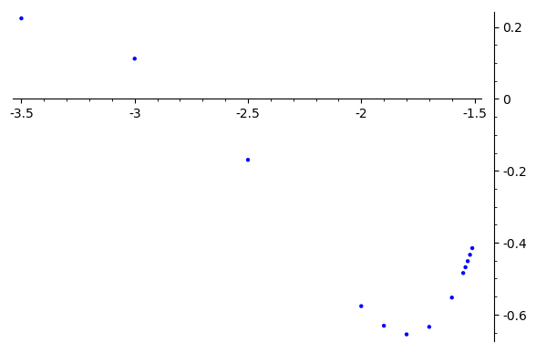

```python
plot_data_rot_H_z = []

Ra = (Rj1 + Rj2) / 2
for dz in (0.01, 0.02, 0.03, 0.04, 0.05, 0.1, 0.2, 0.3, 0.4, 0.5, 1.0, 1.5, 2.0):
    Za = Zj1 - dz
    j_z = calc_rot_H_z(Za, Ra)
    plot_data_rot_H_z += [(Za, j_z)]

list_plot(plot_data_rot_H_z)
```

```
Ra = 0.150000000000000 Za = -1.51000000000000 rot_H_z = -3.383218146572797
Ra = 0.150000000000000 Za = -1.52000000000000 rot_H_z = -2.7703546545603333
Ra = 0.150000000000000 Za = -1.53000000000000 rot_H_z = -2.1637126203623613
Ra = 0.150000000000000 Za = -1.54000000000000 rot_H_z = -1.565977868197475
Ra = 0.150000000000000 Za = -1.55000000000000 rot_H_z = -0.9794667771357188
Ra = 0.150000000000000 Za = -1.60000000000000 rot_H_z = 1.7333074424077175
Ra = 0.150000000000000 Za = -1.70000000000000 rot_H_z = 5.965703224520091
Ra = 0.150000000000000 Za = -1.80000000000000 rot_H_z = 8.86702271527603
Ra = 0.150000000000000 Za = -1.90000000000000 rot_H_z = 10.720209028404684
Ra = 0.150000000000000 Za = -2.00000000000000 rot_H_z = 11.752998376278633
Ra = 0.150000000000000 Za = -2.50000000000000 rot_H_z = 10.916119381871766
Ra = 0.150000000000000 Za = -3.00000000000000 rot_H_z = 7.8934723971408225
Ra = 0.150000000000000 Za = -3.50000000000000 rot_H_z = 5.512706209909056
```

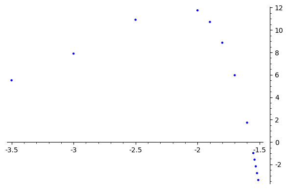

```python
plot_data_rot_H_z = []

Ra = (Rj1) / 2
for dz in (0.01, 0.02, 0.03, 0.04, 0.05, 0.1, 0.2, 0.3, 0.4, 0.5, 1.0, 1.5, 2.0):
    Za = Zj1 - dz
    j_z = calc_rot_H_z(Za, Ra)
    plot_data_rot_H_z += [(Za, j_z)]

list_plot(plot_data_rot_H_z)
```

```
Ra = 0.0300000000000000 Za = -1.51000000000000 rot_H_z = -16.049420478430136
Ra = 0.0300000000000000 Za = -1.52000000000000 rot_H_z = -11.23601154109833
Ra = 0.0300000000000000 Za = -1.53000000000000 rot_H_z = -6.456252792955619
Ra = 0.0300000000000000 Za = -1.54000000000000 rot_H_z = -1.7259286641697464
Ra = 0.0300000000000000 Za = -1.55000000000000 rot_H_z = 2.9398614936641536
Ra = 0.0300000000000000 Za = -1.60000000000000 rot_H_z = 24.841975763668113
Ra = 0.0300000000000000 Za = -1.70000000000000 rot_H_z = 58.40797994357918
Ra = 0.0300000000000000 Za = -1.80000000000000 rot_H_z = 77.67386341829125
Ra = 0.0300000000000000 Za = -1.90000000000000 rot_H_z = 86.36745900883872
Ra = 0.0300000000000000 Za = -2.00000000000000 rot_H_z = 88.52652386877224
Ra = 0.0300000000000000 Za = -2.50000000000000 rot_H_z = 68.26508300369596
Ra = 0.0300000000000000 Za = -3.00000000000000 rot_H_z = 45.562959272480015
Ra = 0.0300000000000000 Za = -3.50000000000000 rot_H_z = 30.459340256531597
```

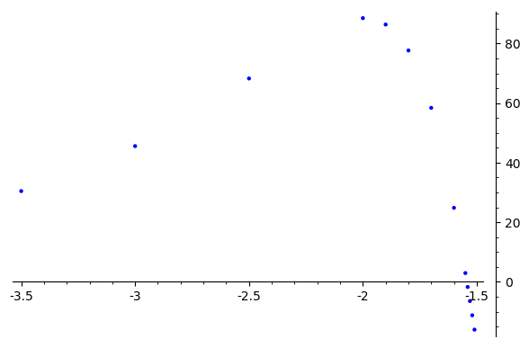

```python
plot_data_rot_H_z = []

Ra = (Rj1) / 10
for dz in (0.01, 0.02, 0.03, 0.04, 0.05, 0.1, 0.2, 0.3, 0.4, 0.5, 1.0, 1.5, 2.0):
    Za = Zj1 - dz
    j_z = calc_rot_H_z(Za, Ra)
    plot_data_rot_H_z += [(Za, j_z)]

list_plot(plot_data_rot_H_z)
```

```
Ra = 0.00300000000000000 Za = -1.51000000000000 rot_H_z = -154.53426705579332
Ra = 0.00300000000000000 Za = -1.52000000000000 rot_H_z = -98.76800967310403
Ra = 0.00300000000000000 Za = -1.53000000000000 rot_H_z = -43.45020193885336
Ra = 0.00300000000000000 Za = -1.54000000000000 rot_H_z = 11.208471901918344
Ra = 0.00300000000000000 Za = -1.55000000000000 rot_H_z = 65.00763743675495
Ra = 0.00300000000000000 Za = -1.60000000000000 rot_H_z = 315.13763505355587
Ra = 0.00300000000000000 Za = -1.70000000000000 rot_H_z = 683.8669519851097
Ra = 0.00300000000000000 Za = -1.80000000000000 rot_H_z = 878.9605763194085
Ra = 0.00300000000000000 Za = -1.90000000000000 rot_H_z = 955.1668488254779
Ra = 0.00300000000000000 Za = -2.00000000000000 rot_H_z = 963.0470036127904
Ra = 0.00300000000000000 Za = -2.50000000000000 rot_H_z = 713.4146307173538
Ra = 0.00300000000000000 Za = -3.00000000000000 rot_H_z = 468.51559918705453
Ra = 0.00300000000000000 Za = -3.50000000000000 rot_H_z = 310.49832113299453
```

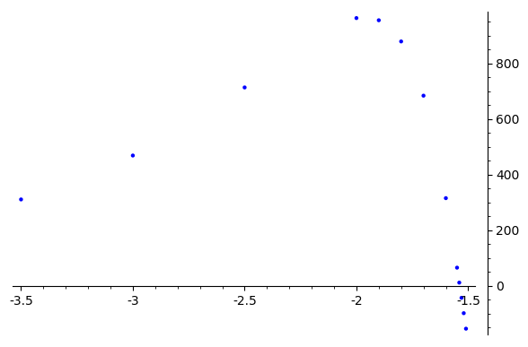

```python
plot_data_rot_H_z = []

Ra = (Rj1) / 100
for dz in (0.01, 0.02, 0.03, 0.04, 0.05, 0.1, 0.2, 0.3, 0.4, 0.5, 1.0, 1.5, 2.0):
    Za = Zj1 - dz
    j_z = calc_rot_H_z(Za, Ra)
    plot_data_rot_H_z += [(Za, j_z)]

list_plot(plot_data_rot_H_z)
```

```
Ra = 3.00000000000000 Za = -1.51000000000000 rot_H_z = 0.02738344536164429
Ra = 3.00000000000000 Za = -1.52000000000000 rot_H_z = 0.026086804877613542
Ra = 3.00000000000000 Za = -1.53000000000000 rot_H_z = 0.024791735534310598
Ra = 3.00000000000000 Za = -1.54000000000000 rot_H_z = 0.02349846128535922
Ra = 3.00000000000000 Za = -1.55000000000000 rot_H_z = 0.02220720544868245
Ra = 3.00000000000000 Za = -1.60000000000000 rot_H_z = 0.015788959707442513
Ra = 3.00000000000000 Za = -1.70000000000000 rot_H_z = 0.0032291792039607706
Ra = 3.00000000000000 Za = -1.80000000000000 rot_H_z = -0.008791140209263415
Ra = 3.00000000000000 Za = -1.90000000000000 rot_H_z = -0.020089001828130906
Ra = 3.00000000000000 Za = -2.00000000000000 rot_H_z = -0.030512638863027047
Ra = 3.00000000000000 Za = -2.50000000000000 rot_H_z = -0.06672708060313437
Ra = 3.00000000000000 Za = -3.00000000000000 rot_H_z = -0.07737557017263377
Ra = 3.00000000000000 Za = -3.50000000000000 rot_H_z = -0.07127200636434289
```

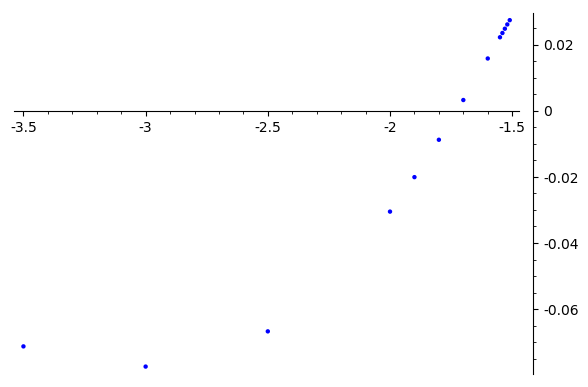

```python
plot_data_rot_H_z = []

Ra = (Rj2) * 2
for dz in (0.01, 0.02, 0.03, 0.04, 0.05, 0.1, 0.2, 0.3, 0.4, 0.5, 1.0, 1.5, 2.0):
    Za = Zj1 - dz
    j_z = calc_rot_H_z(Za, Ra)
    plot_data_rot_H_z += [(Za, j_z)]

list_plot(plot_data_rot_H_z)
```

Ниже представлена процедура вычисления $r$-компоненты плотности тока смещения исходя из ротора напряженности магнитного поля

```python
At2_diff_za_diff_za = lambda I0, rj, ra, zj1, zj2, za : At2_diff_za (I0, rj, ra, zj1, zj2, za).diff(za)
```

```python
As2_diff_ra_diff_za = lambda I0, rj1, rj2, ra, zj, za : As2_diff_ra (I0, rj1, rj2, ra, zj, za).diff(za)
```

```python
exec(preparse("At_diff_za_diff_za_subs_zj = lambda rj, ra, za : " + str(At2_diff_za_diff_za (1, rj, ra, Zj1, Zj2, za))))
```

```python
exec(preparse("As_diff_ra_diff_za_subs_rj = lambda ra, zj, za : " + str(As2_diff_ra_diff_za (1, Rj1, Rj2, ra, zj, za))))
```

```python
exec(preparse("Av_diff_ra_diff_za = lambda I0, rj, ra, zj, za : " + str(Av_diff_ra(I0, rj, ra, zj, za).diff(za))))
```

```python
AV_diff_ra_diff_za = lambda I0, rj1, rj2, ra, zj, za : num_int(lambda rj : Av_diff_ra_diff_za(I0, rj, ra, zj, za), rj1, rj2)
```

```python
Av_diff_ra_diff_za_subs_rj = lambda ra, zj, za : AV_diff_ra_diff_za (1, Rj1, Rj2, ra, zj, za)
```

```python
def calc_rot_H_r(Za, Ra):
    At_diff_za_subs_zj_diff_za_subs_za_ra = lambda rj : At_diff_za_diff_za_subs_zj(rj, Ra, Za)
    As_diff_ra_subs_rj_diff_za_subs_za_ra = lambda zj : As_diff_ra_diff_za_subs_rj(Ra, zj, Za)

    At_diff_za_diff_za_num_int = At_diff_za_subs_zj_diff_za_subs_za_ra(rj).nintegral(rj, Rj1, Rj2)
    As_diff_ra_diff_za_num_int = As_diff_ra_subs_rj_diff_za_subs_za_ra(zj).nintegral(zj, Zj1, Zj2)
    Av_diff_ra_diff_za_num_int = num_int( lambda zj : Av_diff_ra_diff_za_subs_rj(Ra, zj, Za), Zj1, Zj2)
    As_v_diff_ra_diff_za_num_int = As_diff_ra_diff_za_num_int[0] + Av_diff_ra_diff_za_num_int

    rot_H_r = - At_diff_za_diff_za_num_int[0] + As_v_diff_ra_diff_za_num_int

    print ("Ra =", Ra, "Za =", Za, "rot_H_r =", rot_H_r)

    return rot_H_r
```

График $r$-компоненты плотности тока смещения (исходя из ротора напряженности магнитного поля) вне материала тороидально намагниченного цилиндра в зависимости от $z$ координаты для радиальной координаты центра тела тороида

```
Ra = 0.900000000000000 Za = -1.51000000000000 rot_H_r = 3.792004635515948
Ra = 0.900000000000000 Za = -1.52000000000000 rot_H_r = 3.7142241628163113
Ra = 0.900000000000000 Za = -1.53000000000000 rot_H_r = 3.6371699092424397
Ra = 0.900000000000000 Za = -1.54000000000000 rot_H_r = 3.5608671380679793
Ra = 0.900000000000000 Za = -1.55000000000000 rot_H_r = 3.485339658077046
Ra = 0.900000000000000 Za = -1.60000000000000 rot_H_r = 3.1200605705772926
Ra = 0.900000000000000 Za = -1.70000000000000 rot_H_r = 2.457107341129122
Ra = 0.900000000000000 Za = -1.80000000000000 rot_H_r = 1.8892243575893701
Ra = 0.900000000000000 Za = -1.90000000000000 rot_H_r = 1.4136650557245103
Ra = 0.900000000000000 Za = -2.00000000000000 rot_H_r = 1.0221248799285627
Ra = 0.900000000000000 Za = -2.50000000000000 rot_H_r = -0.029133701913133248
Ra = 0.900000000000000 Za = -3.00000000000000 rot_H_r = -0.28671679115847326
Ra = 0.900000000000000 Za = -3.50000000000000 rot_H_r = -0.2895888430304817
```

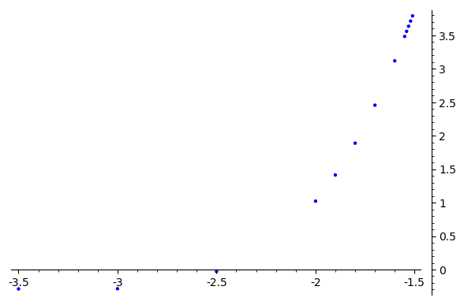

```python
plot_data_rot_H_r = []

Ra = (Rj1 + Rj2) / 2
for dz in (0.01, 0.02, 0.03, 0.04, 0.05, 0.1, 0.2, 0.3, 0.4, 0.5, 1.0, 1.5, 2.0):
    Za = Zj1 - dz
    j_r = calc_rot_H_r(Za, Ra)
    plot_data_rot_H_r += [(Za, j_r)]

list_plot(plot_data_rot_H_r).show()
```

Теперь представляет интерес двумерная визуализация скалярного и векторного магнитного полей а также тока смещения (ротора $H$)

```python
import numpy as np
import matplotlib.pyplot as plt
%matplotlib inline

za_linspace = np.linspace(-3, +3, 40)
ra_linspace = np.linspace(0.1, 3,   10)

za_list = za_linspace.tolist()
ra_list = ra_linspace.tolist()

za_grid,ra_grid = np.meshgrid(za_linspace, ra_linspace)

u = za_grid * np.nan
v = ra_grid * np.nan
s = ra_grid * np.nan
s_t = ra_grid * np.nan
s_s = ra_grid * np.nan
h = ra_grid * np.nan
h_t = ra_grid * np.nan
h_s = ra_grid * np.nan

for iz in np.arange(0, len(za_linspace), 1):
    for ir in np.arange(0, len(ra_linspace), 1):
        Za = za_list[iz]
        Ra = ra_list[ir]
        u[ir][iz] = calc_rot_H_z(Za, Ra)
        v[ir][iz] = calc_rot_H_r(Za, Ra)

        h_scalar = calc_H_scalar(Za, Ra)
        s  [ir][iz] = h_scalar[0]
        s_t[ir][iz] = h_scalar[1]
        s_s[ir][iz] = h_scalar[2]

        h_phi = calc_H_phi(At_diff_za_subs_zj, As_diff_ra_subs_rj, Za, Ra)
        h  [ir][iz] = h_phi[0]
        h_t[ir][iz] = h_phi[1]
        h_s[ir][iz] = h_phi[2]
```

```
Ra = 0.1 Za = -3.0 rot_H_z = 12.620476477634611
Ra = 0.1 Za = -3.0 rot_H_r = -1.0780942994611025
Ra = 0.1 Za = -3.0 H_scalar_t = -22.41584731012706
Ra = 0.1 Za = -3.0 H_scalar_s = 1.0030219116011958
Ra = 0.1 Za = -3.0 H_scalar   = -21.412825398525865
Ra = 0.1 Za = -3.0 H_phi_t = 1.4070140847156
Ra = 0.1 Za = -3.0 H_phi_s = -0.07000214066967266
Ra = 0.1 Za = -3.0 H_phi   = 1.3370119440459274
Ra = 0.42222222222222217 Za = -3.0 rot_H_z = 1.766040981812357
Ra = 0.42222222222222217 Za = -3.0 rot_H_r = -0.708395293095295
Ra = 0.42222222222222217 Za = -3.0 H_scalar_t = -4.955581910077284
Ra = 0.42222222222222217 Za = -3.0 H_scalar_s = 0.9086356981487658
Ra = 0.42222222222222217 Za = -3.0 H_scalar   = -4.0469462119285184
Ra = 0.42222222222222217 Za = -3.0 H_phi_t = 1.359968224119479
Ra = 0.42222222222222217 Za = -3.0 H_phi_s = -0.2764087979139108
Ra = 0.42222222222222217 Za = -3.0 H_phi   = 1.0835594262055683
Ra = 0.7444444444444444 Za = -3.0 rot_H_z = 0.377934571726084
Ra = 0.7444444444444444 Za = -3.0 rot_H_r = -0.4035660538392909
Ra = 0.7444444444444444 Za = -3.0 H_scalar_t = -2.382502931005904
Ra = 0.7444444444444444 Za = -3.0 H_scalar_s = 0.7245714768534863
Ra = 0.7444444444444444 Za = -3.0 H_scalar   = -1.6579314541524177
Ra = 0.7444444444444444 Za = -3.0 H_phi_t = 1.252475062901707
Ra = 0.7444444444444444 Za = -3.0 H_phi_s = -0.4194064161376686
Ra = 0.7444444444444444 Za = -3.0 H_phi   = 0.8330686467640384
Ra = 1.0666666666666667 Za = -3.0 rot_H_z = -0.0534376129746057
Ra = 1.0666666666666667 Za = -3.0 rot_H_r = -0.1831248968878464
Ra = 1.0666666666666667 Za = -3.0 H_scalar_t = -1.246432771610334
Ra = 1.0666666666666667 Za = -3.0 H_scalar_s = 0.5012359138190943
Ra = 1.0666666666666667 Za = -3.0 H_scalar   = -0.7451968577912398
Ra = 1.0666666666666667 Za = -3.0 H_phi_t = 1.087494757625962
Ra = 1.0666666666666667 Za = -3.0 H_phi_s = -0.47570423981397353
Ra = 1.0666666666666667 Za = -3.0 H_phi   = 0.6117905178119885
Ra = 1.3888888888888888 Za = -3.0 rot_H_z = -0.18695580384684607
Ra = 1.3888888888888888 Za = -3.0 rot_H_r = -0.03939131093903381
Ra = 1.3888888888888888 Za = -3.0 H_scalar_t = -0.6024564469251357
Ra = 1.3888888888888888 Za = -3.0 H_scalar_s = 0.2917821901474311
Ra = 1.3888888888888888 Za = -3.0 H_scalar   = -0.31067425677770455
Ra = 1.3888888888888888 Za = -3.0 H_phi_t = 0.8825655933000564
Ra = 1.3888888888888888 Za = -3.0 H_phi_s = -0.45191460603407807
Ra = 1.3888888888888888 Za = -3.0 H_phi   = 0.4306509872659783
```

[output cut: 754 more lines]

```
Ra = 3.0 Za = -1.6153846153846154 H_scalar_t = 0.3440049312508012
Ra = 3.0 Za = -1.6153846153846154 H_scalar_s = -0.1832034122186288
Ra = 3.0 Za = -1.6153846153846154 H_scalar   = 0.16080151903217244
Ra = 3.0 Za = -1.6153846153846154 H_phi_t = -0.224636121817483
Ra = 3.0 Za = -1.6153846153846154 H_phi_s = 0.04214674440277899
Ra = 3.0 Za = -1.6153846153846154 H_phi   = -0.182489377414704
Ra = 0.1 Za = -1.4615384615384615 rot_H_z = -10.201282866029004
Ra = 0.1 Za = -1.4615384615384615 rot_H_r = 13.075802313323655
Ra = 0.1 Za = -1.4615384615384615 H_scalar_t = -55.01719637756053
Ra = 0.1 Za = -1.4615384615384615 H_scalar_s = 10.068107943803422
Ra = 0.1 Za = -1.4615384615384615 H_scalar   = -44.94908843375711
Ra = 0.1 Za = -1.4615384615384615 H_phi_t = -1.354163317603994
Ra = 0.1 Za = -1.4615384615384615 H_phi_s = 0.22079884742457137
Ra = 0.1 Za = -1.4615384615384615 H_phi   = -1.1333644701794225
Ra = 0.42222222222222217 Za = -1.4615384615384615 rot_H_z = -31.181049399605698
```

```
Ra = 0.42222222222222217 Za = -1.4615384615384615 rot_H_r = 8.068616509061346
Ra = 0.42222222222222217 Za = -1.4615384615384615 H_scalar_t = -15.67663969599365
Ra = 0.42222222222222217 Za = -1.4615384615384615 H_scalar_s = 9.956408047185985
Ra = 0.42222222222222217 Za = -1.4615384615384615 H_scalar   = -5.720231648807665
Ra = 0.42222222222222217 Za = -1.4615384615384615 H_phi_t = -6.444824451621657
Ra = 0.42222222222222217 Za = -1.4615384615384615 H_phi_s = -7.037076922882557
Ra = 0.42222222222222217 Za = -1.4615384615384615 H_phi   = -13.481901374504215
Ra = 0.7444444444444444 Za = -1.4615384615384615 rot_H_z = -17.36673026752861
```

```
Ra = 0.7444444444444444 Za = -1.4615384615384615 rot_H_r = 4.605503357714775
Ra = 0.7444444444444444 Za = -1.4615384615384615 H_scalar_t = -7.114200818698563
Ra = 0.7444444444444444 Za = -1.4615384615384615 H_scalar_s = 5.7348818414310925
Ra = 0.7444444444444444 Za = -1.4615384615384615 H_scalar   = -1.37931897726747
Ra = 0.7444444444444444 Za = -1.4615384615384615 H_phi_t = -6.658732788674512
Ra = 0.7444444444444444 Za = -1.4615384615384615 H_phi_s = -6.625676221633034
Ra = 0.7444444444444444 Za = -1.4615384615384615 H_phi   = -13.284409010307545
Ra = 1.0666666666666667 Za = -1.4615384615384615 rot_H_z = -11.991718059264787
Ra = 1.0666666666666667 Za = -1.4615384615384615 rot_H_r = 2.766635334474822
Ra = 1.0666666666666667 Za = -1.4615384615384615 H_scalar_t = -2.7435401790512
Ra = 1.0666666666666667 Za = -1.4615384615384615 H_scalar_s = 2.5889980804046
Ra = 1.0666666666666667 Za = -1.4615384615384615 H_scalar   = -0.15454209864659996
Ra = 1.0666666666666667 Za = -1.4615384615384615 H_phi_t = -6.563971407164233
Ra = 1.0666666666666667 Za = -1.4615384615384615 H_phi_s = -6.591596997954092
Ra = 1.0666666666666667 Za = -1.4615384615384615 H_phi   = -13.155568405118325
Ra = 1.3888888888888888 Za = -1.4615384615384615 rot_H_z = -9.114996219857337
Ra = 1.3888888888888888 Za = -1.4615384615384615 rot_H_r = 1.6552916104013171
Ra = 1.3888888888888888 Za = -1.4615384615384615 H_scalar_t = 1.859031585358056
Ra = 1.3888888888888888 Za = -1.4615384615384615 H_scalar_s = -1.6098664011547665
Ra = 1.3888888888888888 Za = -1.4615384615384615 H_scalar   = 0.24916518420328937
Ra = 1.3888888888888888 Za = -1.4615384615384615 H_phi_t = -6.011444856395675
Ra = 1.3888888888888888 Za = -1.4615384615384615 H_phi_s = -7.044655827787168
Ra = 1.3888888888888888 Za = -1.4615384615384615 H_phi   = -13.056100684182844
Ra = 1.711111111111111 Za = -1.4615384615384615 rot_H_z = -0.01972529998123962
Ra = 1.711111111111111 Za = -1.4615384615384615 rot_H_r = 0.9255868523680668
Ra = 1.711111111111111 Za = -1.4615384615384615 H_scalar_t = 2.058423895895593
Ra = 1.711111111111111 Za = -1.4615384615384615 H_scalar_s = -1.735540124053852
Ra = 1.711111111111111 Za = -1.4615384615384615 H_scalar   = 0.3228837718417412
Ra = 1.711111111111111 Za = -1.4615384615384615 H_phi_t = -0.734701643130579
Ra = 1.711111111111111 Za = -1.4615384615384615 H_phi_s = 0.32812581352540704
Ra = 1.711111111111111 Za = -1.4615384615384615 H_phi   = -0.4065758296051719
Ra = 2.033333333333333 Za = -1.4615384615384615 rot_H_z = 0.005884899223147583
Ra = 2.033333333333333 Za = -1.4615384615384615 rot_H_r = 0.577724252073631
Ra = 2.033333333333333 Za = -1.4615384615384615 H_scalar_t = 1.05258803220609
Ra = 2.033333333333333 Za = -1.4615384615384615 H_scalar_s = -0.7618424460340152
Ra = 2.033333333333333 Za = -1.4615384615384615 H_scalar   = 0.2907455861720749
Ra = 2.033333333333333 Za = -1.4615384615384615 H_phi_t = -0.4942231361442806
Ra = 2.033333333333333 Za = -1.4615384615384615 H_phi_s = 0.15025922635224465
Ra = 2.033333333333333 Za = -1.4615384615384615 H_phi   = -0.34396390979203595
Ra = 2.3555555555555556 Za = -1.4615384615384615 rot_H_z = 0.02261590663801588
```

[output cut: 2328 more lines]

```
Ra = 2.6777777777777776 Za = 3.0 rot_H_r = -0.09870511824011155
Ra = 2.6777777777777776 Za = 3.0 H_scalar_t = -0.1363272897300732
Ra = 2.6777777777777776 Za = 3.0 H_scalar_s = 0.04592620098206357
Ra = 2.6777777777777776 Za = 3.0 H_scalar   = -0.09040108874800962
Ra = 2.6777777777777776 Za = 3.0 H_phi_t = 0.2051354007187332
Ra = 2.6777777777777776 Za = 3.0 H_phi_s = -0.14222107135472406
Ra = 2.6777777777777776 Za = 3.0 H_phi   = 0.06291432936400915
Ra = 3.0 Za = 3.0 rot_H_z = -0.07737557017263386
Ra = 3.0 Za = 3.0 rot_H_r = -0.09054542959770362
Ra = 3.0 Za = 3.0 H_scalar_t = -0.1472615456317825
Ra = 3.0 Za = 3.0 H_scalar_s = 0.052415286029803276
Ra = 3.0 Za = 3.0 H_scalar   = -0.09484625960197923
Ra = 3.0 Za = 3.0 H_phi_t = 0.1244170720831013
Ra = 3.0 Za = 3.0 H_phi_s = -0.09597714842464367
Ra = 3.0 Za = 3.0 H_phi   = 0.028439923658457628
```

```python
line_thick = 0.005
arr_l = 0.15
arr_h = 0.025
color = "red"

def matplotlib_draw_cylinder(plt, z0 = 0):
    plt.plot(z0 + Zj1,      Rj2                 , z0 + Zj2,Rj2, marker='.', color = color)
    plt.plot(z0 + Zj2,      Rj2                 , z0 + Zj2,Rj1, marker='.', color = color, linestyle="dashed")
    plt.plot(z0 + Zj2,      Rj1                 , z0 + Zj1,Rj1, marker='.', color = color)
    plt.plot(z0 + Zj1,      Rj1                 , z0 + Zj1,Rj2, marker='.', color = color, linestyle="dashed")
```

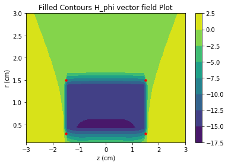

```python
fig,ax=plt.subplots(1,1)
matplotlib_draw_cylinder(ax, z0 = 0)
cp = ax.contourf(za_grid,ra_grid, h)
fig.colorbar(cp) # Add a colorbar to a plot
ax.set_title('Filled Contours H_phi vector field Plot')
ax.set_xlabel('z (cm)')
ax.set_ylabel('r (cm)')
plt.show()
```

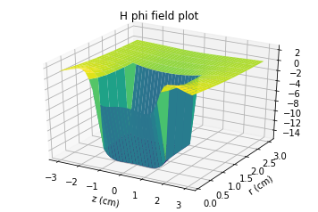

```python
from mpl_toolkits import mplot3d
import numpy as np
import matplotlib.pyplot as plt
fig = plt.figure()

ax = plt.axes(projection='3d')
ax.set_xlabel('z (cm)')
ax.set_ylabel('r (cm)')
ax.plot_surface(za_grid,ra_grid, h, cmap='viridis', edgecolor='none')
ax.set_title('H phi field plot')
plt.show()
```

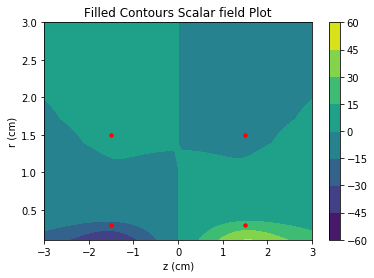

```python
fig,ax=plt.subplots(1,1)
matplotlib_draw_cylinder(ax, z0 = 0)
cp = ax.contourf(za_grid,ra_grid, s)
fig.colorbar(cp) # Add a colorbar to a plot
ax.set_title('Filled Contours Scalar field Plot')
ax.set_xlabel('z (cm)')
ax.set_ylabel('r (cm)')
plt.show()
```

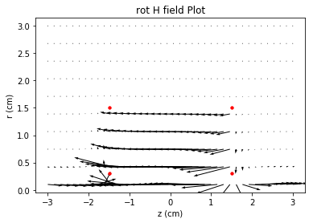

```python
fig,ax=plt.subplots(1,1)
matplotlib_draw_cylinder(ax, z0 = 0)
ax.quiver(za_grid,ra_grid,u,v)
ax.set_title('rot H field Plot')
ax.set_xlabel('z (cm)')
ax.set_ylabel('r (cm)')
plt.show()
```

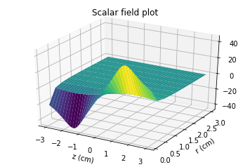

```python
from mpl_toolkits import mplot3d
import numpy as np
import matplotlib.pyplot as plt
fig = plt.figure()

ax = plt.axes(projection='3d')
ax.set_xlabel('z (cm)')
ax.set_ylabel('r (cm)')
ax.plot_surface(za_grid,ra_grid, s, cmap='viridis', edgecolor='none')
ax.set_title('Scalar field plot')
plt.show()
```

[figure not shown]

```python
fig,ax=plt.subplots(1,1)
matplotlib_draw_cylinder(ax, z0 = 0)
cp = ax.contourf(za_grid,ra_grid, s_t)
fig.colorbar(cp) # Add a colorbar to a plot
ax.set_title('Filled Contours Scalar_t field Plot')
ax.set_xlabel('z (cm)')
ax.set_ylabel('r (cm)')
plt.show()
```

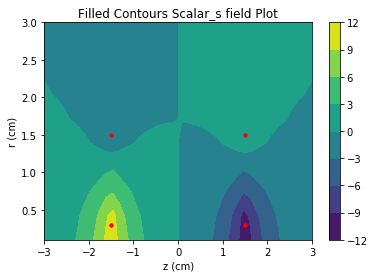

```python
fig,ax=plt.subplots(1,1)
matplotlib_draw_cylinder(ax, z0 = 0)
cp = ax.contourf(za_grid,ra_grid, s_s)
fig.colorbar(cp) # Add a colorbar to a plot
ax.set_title('Filled Contours Scalar_s field Plot')
ax.set_xlabel('z (cm)')
ax.set_ylabel('r (cm)')
plt.show()
```

```python
u_ex = u
v_ex = v
s_ex = s
h_ex = h

for iz in np.arange(0, len(za_linspace), 1):
    for ir in np.arange(0, len(ra_linspace), 1):
        Za = za_list[iz]
        Ra = ra_list[ir]
        if Za >= Zj1 and Za <= Zj2 and Ra >= Rj1 and Ra <= Rj2:
            u_ex[ir][iz] = np.nan
            v_ex[ir][iz] = np.nan
            s_ex[ir][iz] = np.nan
            h_ex[ir][iz] = np.nan
```

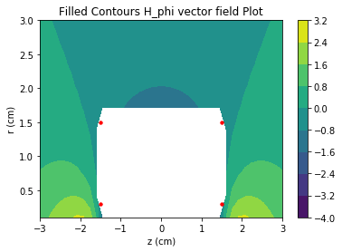

```python
fig,ax=plt.subplots(1,1)
matplotlib_draw_cylinder(ax, z0 = 0)
cp = ax.contourf(za_grid,ra_grid, h_ex)
fig.colorbar(cp) # Add a colorbar to a plot
ax.set_title('Filled Contours H_phi vector field Plot')
ax.set_xlabel('z (cm)')
ax.set_ylabel('r (cm)')
plt.show()
```

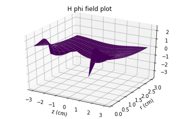

```python
from mpl_toolkits import mplot3d
import numpy as np
import matplotlib.pyplot as plt
fig = plt.figure()

ax = plt.axes(projection='3d')
ax.set_xlabel('z (cm)')
ax.set_ylabel('r (cm)')
ax.plot_surface(za_grid,ra_grid, h_ex, cmap='viridis', edgecolor='none')
ax.set_title('H phi field plot')
plt.show()
```

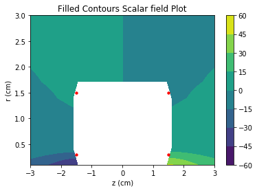

```python
fig,ax=plt.subplots(1,1)
matplotlib_draw_cylinder(ax, z0 = 0)
cp = ax.contourf(za_grid,ra_grid, s_ex)
fig.colorbar(cp) # Add a colorbar to a plot
ax.set_title('Filled Contours Scalar field Plot')
ax.set_xlabel('z (cm)')
ax.set_ylabel('r (cm)')
plt.show()
```

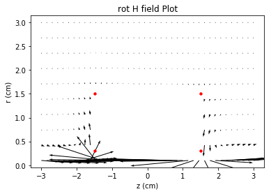

```python
fig,ax=plt.subplots(1,1)
matplotlib_draw_cylinder(ax, z0 = 0)
ax.quiver(za_grid,ra_grid,u_ex,v_ex)
ax.set_title('rot H field Plot')
ax.set_xlabel('z (cm)')
ax.set_ylabel('r (cm)')
plt.show()
```

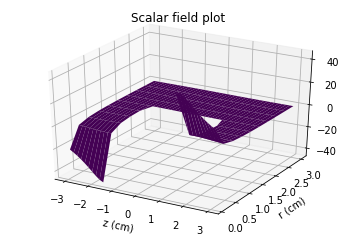

```python
from mpl_toolkits import mplot3d
import numpy as np
import matplotlib.pyplot as plt
fig = plt.figure()

ax = plt.axes(projection='3d')
ax.set_xlabel('z (cm)')
ax.set_ylabel('r (cm)')
ax.plot_surface(za_grid,ra_grid, s_ex, cmap='viridis', edgecolor='none')
ax.set_title('Scalar field plot')
plt.show()
```

```python
u_norm = u
v_norm = v

for iz in np.arange(0, len(za_linspace), 1):
    for ir in np.arange(0, len(ra_linspace), 1):
        n = sqrt(u[ir][iz]^2 + v[ir][iz]^2)
        u_norm[ir][iz] = u[ir][iz] / n
        v_norm[ir][iz] = v[ir][iz] / n
```

[figure not shown]

```python
fig,ax=plt.subplots(1,1)
matplotlib_draw_cylinder(ax, z0 = 0)
ax.quiver(za_grid,ra_grid,u_norm,v_norm)
ax.set_title('rot H normalized field Plot')
ax.set_xlabel('z (cm)')
ax.set_ylabel('r (cm)')
plt.show()
```